# Project_CNB-LoanApprovalPrediction

[figure not shown]

**DataScience Portfolio**  
**Enrique Otero Espinosa**  
**https://github.com/eoroot1974/DataSciencePortfolio**

**Deep Learning Algorithms**  
Binary Classification with AI Deep Learning Algorithms

Project Name:  
Project_CNB-LoanApprovalPrediction  
Project Location:  
[Binary Classification with AI Deep Learning ML Algorithms: Loan Approval Prediction](https://github.com/eoroot1974/DataSciencePortfolio/tree/main/ArtificialIntelligence/ClassificationAIDeepLearningMLBinary/Project_CNB-LoanApprovalPrediction)  
Date:  
September 28th, 2025

**TABLE OF CONTENTS**

Overview  
1. Libraries  
2. Data Loading and Data Description  
3. Exploratory Data Analysis (EDA)  
3.1. Dataset Structure and Data types  
3.2. Basic statistical information  
3.2.1. Statistical Basic Summary  
3.2.2. Outlier Analysis  
3.2.2.1. Initial Outlier Detection  
3.2.2.2 Outlier Handling Methods  
3.3. Graphical dataset analysis  
3.3.1. Variables Graphical analysis - Univariate  
3.3.2. Variables Graphical analysis - Multivariate  
3.4. Correlation Analysis  
3.5. Model Suitability Statistical Tests  
4. Model Training  
5. Model Predictions  
6. Model Results and Evaluation

```python
%%html
<style>
table {float:left}
</style>
```

# Overview

## Loan Approval Prediction: Deep Learning–Based End-to-End Classification Analysis

This project presents a complete **deep learning workflow** designed to predict loan approval outcomes (i.e., whether a borrower will default) using the **Loan Approval Dataset**. It extends the traditional ML pipeline by introducing **neural network architectures** built in both **TensorFlow (Keras)** and **PyTorch**, enabling direct comparison between classical algorithms and deep learning approaches.

The dataset contains demographic, financial, and behavioral attributes for thousands of borrowers. The objective is to train and evaluate high-performance neural classifiers capable of supporting **real-time credit risk decisions** in banking and fintech environments.

### Project Features

**Data Preprocessing and Cleaning** The raw dataset was evaluated for missing values, outliers, inconsistent categories, and class imbalance. Three main cleaned datasets were created:

- **Raw dataset (`loan_data_train`)**
- **Winsorized dataset (`loan_data_train_w`)** – extreme outliers capped
- **IQR-filtered dataset (`loan_data_train_r`)** – outliers removed

**Class Imbalance Handling with SMOTE** Each dataset was balanced using **SMOTE (Synthetic Minority Over-sampling Technique)** to mitigate bias toward non-defaulted loans, producing:

- `loan_data_train_B`, `loan_data_train_w_B`, and `loan_data_train_r_B` Each was further standardized (`_scaled`) for optimal deep learning performance, yielding nine training variants in total.

**Exploratory Data Analysis (EDA)** EDA combined univariate and multivariate visualizations to reveal structure and data quality insights. Included:

- Target imbalance and its correction
- Correlation matrices and multicollinearity inspection
- Outlier detection and distribution analysis
- Feature scaling validation and class separation visualizations
- Model suitability checks for neural feature scaling

### Model Training and Architectures

Instead of traditional ML classifiers, three **neural network architectures** were designed and trained in both frameworks:

| Framework | Architecture | Description |
| --- | --- | --- |
| TensorFlow | **TF_Shallow** | A compact 2-layer dense network for baseline benchmarking |
| TensorFlow | **TF_Deep** | A 4-layer ReLU network with dropout regularization |
| TensorFlow | **TF_BatchNorm** | Deep network with batch normalization for faster convergence |
| PyTorch | **PT_Shallow** | Equivalent shallow NN implemented in PyTorch |
| PyTorch | **PT_Deep** | Deep PyTorch version with 3 hidden layers and dropout |
| PyTorch | **PT_BatchNorm** | Deep PyTorch model using batch normalization |

Each model was trained and validated on every dataset variant, allowing a **cross-framework, cross-architecture performance matrix**.

### Model Evaluation and Selection

All models were evaluated using **accuracy** and summarized in a heatmap for comparison. The **best-performing model** was the **PyTorch Deep network (PT_Deep)** trained on the **IQR-filtered, SMOTE-balanced, and standardized dataset (`loan_data_train_r_B_scaled`)**, achieving an **accuracy of 0.9547**.

Further evaluation included:

- **Classification report** (precision, recall, F1-score)
- **Confusion matrix** for true/false positive analysis
- **ROC curve** with **AUC = 0.983**, confirming strong discriminative power

### Performance Interpretation

The deep neural network achieved:

- **Precision:** 0.98 for defaulted loans → minimal false positives
- **Recall:** 0.93 for defaulted loans → very few missed defaults
- **F1-score:** 0.95 overall → excellent balance between precision and recall

This confirms that the model generalizes effectively across both classes while avoiding overfitting, even with imbalanced financial data.

### Kaggle Submission Workflow

1. **Load and preprocess external test data** (`loan_approval_prediction_test.csv`) standardized to match the training schema.
2. **Align feature set** using one-hot encoding and column reindexing.
3. **Predict** loan approval status using the trained deep learning model.
4. **Export** results as a CSV (`kaggle_submission.csv`) with `id` and predicted labels.

### Purpose

This project demonstrates the transition from traditional ML to **deep learning-based credit risk modeling**. It highlights how neural networks—properly regularized and trained on balanced, standardized data—can deliver **superior predictive accuracy and robustness**, enabling scalable, explainable risk assessment.

### Requirements

Python 3.12 (aarch64) NumPy · Pandas · Matplotlib · Seaborn scikit-learn · imbalanced-learn TensorFlow (Apple Silicon / ARM64 build) PyTorch (ARM64 / MPS or CPU build)

### Conclusion

This end-to-end project validates that **deep learning architectures can outperform traditional classifiers** in credit scoring tasks when paired with rigorous data preprocessing and class balancing. The resulting model not only achieves near-state-of-the-art accuracy but is also production-ready for deployment in banking, lending, or fintech environments where predictive reliability is mission-critical.

# 1. Libraries

```python
# Data manipulation and numerical operations
import os # For OS data files and names manipulation
import numpy as np  # For numerical calculations and generating synthetic data
import pandas as pd  # For handling and manipulating data in tabular format

# Visualization libraries
import matplotlib.pyplot as plt  # For creating data visualizations
import seaborn as sns  # For enhanced data visualizations, like correlation plots

from scipy.stats.mstats import winsorize

from imblearn.over_sampling import SMOTE
from scipy import stats
import statsmodels.api as sm
from statsmodels.stats.outliers_influence import variance_inflation_factor
from statsmodels.tools.tools import add_constant

from sklearn.preprocessing import StandardScaler
from scipy.stats import pointbiserialr
from sklearn.model_selection import train_test_split

import torch
import torch.nn as nn
import torch.optim as optim
from torch.utils.data import TensorDataset, DataLoader
from tensorflow.keras.models import Sequential
from tensorflow.keras.layers import Dense, Dropout, BatchNormalization
from tensorflow.keras.optimizers import Adam
from sklearn.metrics import accuracy_score, classification_report, confusion_matrix, roc_curve, auc
from sklearn.model_selection import train_test_split
from tensorflow.keras.utils import plot_model
from torchsummary import summary

from sklearn.inspection import permutation_importance

# To ignore warnings (optional)
import warnings
warnings.filterwarnings('ignore')  # To suppress warnings for cleaner output
```

# 2. Data Loading and Data Description

```python
# Load the dataset from the CSV file
data_path = '/home/dsninja/Documents/Shared/WorkArea/Anaconda/JupiterProjects/Project_CNB-LoanApprovalPrediction/data'
date_file_name = 'loan_approval_prediction_train.csv'

full_file_path = os.path.join(data_path, date_file_name)
loan_data = pd.read_csv(full_file_path)

# Display the first few rows to inspect the data
loan_data.head()
```

|  | id | person_age | person_income | person_home_ownership | person_emp_length | loan_intent | loan_grade | loan_amnt | loan_int_rate | loan_percent_income | cb_person_default_on_file | cb_person_cred_hist_length | loan_status |
| --- | --- | --- | --- | --- | --- | --- | --- | --- | --- | --- | --- | --- | --- |
| 0 | 0 | 37 | 35000 | RENT | 0.0 | EDUCATION | B | 6000 | 11.49 | 0.17 | N | 14 | 0 |
| 1 | 1 | 22 | 56000 | OWN | 6.0 | MEDICAL | C | 4000 | 13.35 | 0.07 | N | 2 | 0 |
| 2 | 2 | 29 | 28800 | OWN | 8.0 | PERSONAL | A | 6000 | 8.90 | 0.21 | N | 10 | 0 |
| 3 | 3 | 30 | 70000 | RENT | 14.0 | VENTURE | B | 12000 | 11.11 | 0.17 | N | 5 | 0 |
| 4 | 4 | 22 | 60000 | RENT | 2.0 | MEDICAL | A | 6000 | 6.92 | 0.10 | N | 3 | 0 |

**Explanation of the Dataset columns**

| Variable Name | Variable Description | Variable Type | Unit | CL type |
| --- | --- | --- | --- | --- |
| **id** | Unique identifier for each record in the dataset. | Integer | None | Independent |
| **person_age** | Age of the individual applying for the loan. | Numeric (integer) | years | Independent |
| **person_income** | Annual income of the individual in dollars. | Numeric (integer) | USD | Independent |
| **person_home_ownership** | Type of home ownership status of the individual | Categorical (string) | None | Independent |
| **person_emp_length** | Length of employment of the individual in years. | Numeric (float) | years | Independent |
| **loan_intent** | The purpose for which the loan is being requested. | Categorical (string) | None | Independent |
| **loan_grade** | Grade assigned to the loan by the lending system. | Categorical (string) | None | Independent |
| **loan_amnt** | The amount of money requested for the loan. | Numeric (integer) | USD | Independent |
| **loan_int_rate** | Interest rate assigned to the loan, in percentage. | Numeric (float) | % | Independent |
| **loan_percent_income** | Ratio of loan amount to annual income, in percentage. | Numeric (float) | % | Independent |
| **cb_person_default_on_file** | Whether the individual has a history of default recorded. | Categorical (string) | None | Independent |
| **cb_person_cred_hist_lengthd** | Length of the individual's credit history, in years. | Numeric (integer) | years | Independent |
| **loan_status** | Target variable indicating the loan's outcome: defaulted (1) or not (0). | Categorical (binary) | None | ___Dependent___ |

# 3. Exploratory Data analysis (EDA)

## 3.1. Dataset Structure and Data types

```python
# Display the shape (dimensions) of the dataset
print("Dataset shape:", loan_data.shape)

# Display the data types of each column
print("\nData types:\n", loan_data.dtypes)
```

```
Dataset shape: (58645, 13)

Data types:
 id                              int64
person_age                      int64
person_income                   int64
person_home_ownership          object
person_emp_length             float64
loan_intent                    object
loan_grade                     object
loan_amnt                       int64
loan_int_rate                 float64
loan_percent_income           float64
cb_person_default_on_file      object
cb_person_cred_hist_length      int64
loan_status                     int64
dtype: object
```

The following information can be extracted:  
**Dataset Shape: (58645, 13)** The dataset has 58,645 rows and 13 columns. Each row represents a single observation of an individual's loan application details. The first 12 columns contain features describing the individual, their loan, and their credit history. The 13th column, *loan_status*, is the target variable, with the loan's outcome: **defaulted** (1) or **not defaulted** (0).

**Data Types:**  
id: **int64**. This column contains unique identifiers for each observation, stored as integers.  
person_age: **int64**. The age of the individual, stored as integers, representing whole numbers.  
person_income: **int64**. The individual's annual income, represented as integers in dollars.  
person_home_ownership: **object**. This column indicates the individual's homeownership status, stored as categorical text values (e.g., 'rent,' 'own').  
person_emp_length: **float64**. Length of employment in years, stored as a floating-point number to allow for fractional years.  
loan_intent: **object**. The purpose for the loan, stored as categorical text values (e.g., 'education,' 'medical').  
loan_grade: **object**. The credit grade assigned to the loan, represented as categorical text values (e.g., 'A,' 'B').  
loan_amnt: **int64**. The loan amount requested by the individual, stored as integers.  
loan_int_rate: **float64**. The interest rate for the loan, stored as a floating-point number for precision (e.g., 12.34%).  
loan_percent_incom: **float64**. The ratio of the loan amount to the individual's annual income, expressed as a percentage and stored as a floating-point number.  
cb_person_default_on_file: **object**. Indicates whether the individual has a history of default recorded in their credit bureau file, stored as categorical text values ('Y' for Yes, 'N' for No).  
cb_person_cred_hist_length: **int64**. The length of the individual's credit history in years, stored as integers.

loan_status: **int64**. The target variable indicating the loan's outcome: 0 for loans not defaulted and 1 for defaulted, stored as integers.

As the target variable loan_status is cathegorical binary, we can convert it to this type using the following code. This conversion is particularly useful when preparing data for tasks like classification, where the target column represents discrete categories.

```python
loan_data['loan_status'] = loan_data['loan_status'].astype('category')
loan_data['loan_status'].dtypes
```

```
CategoricalDtype(categories=[0, 1], ordered=False, categories_dtype=int64)
```

**Null or NaN values in Dataset**  
You can check for null or NaN values in your dataset using the isnull() and sum() functions from pandas. Here’s the code to find if there are any null or NaN values in your dataset:

```python
# Check for null or NaN values in the dataset
null_values = loan_data.isnull().sum()

# Display the result
print("Null or NaN values in the dataset:\n", null_values)
```

```
Null or NaN values in the dataset:
 id                            0
person_age                    0
person_income                 0
person_home_ownership         0
person_emp_length             0
loan_intent                   0
loan_grade                    0
loan_amnt                     0
loan_int_rate                 0
loan_percent_income           0
cb_person_default_on_file     0
cb_person_cred_hist_length    0
loan_status                   0
dtype: int64
```

No Null or Nan values are found in the dataset.

## 3.2. Basic statistical information

### 3.2.1. Statistical Basic Summary

```python
# Get basic statistical information about the dataset
statistical_summary = loan_data.describe()

# Display the result
statistical_summary.style.set_caption("Statistical Summary")
```

Statistical Summary

|  | id | person_age | person_income | person_emp_length | loan_amnt | loan_int_rate | loan_percent_income | cb_person_cred_hist_length |
| --- | --- | --- | --- | --- | --- | --- | --- | --- |
| count | 58645.000000 | 58645.000000 | 58645.000000 | 58645.000000 | 58645.000000 | 58645.000000 | 58645.000000 | 58645.000000 |
| mean | 29322.000000 | 27.550857 | 64046.172871 | 4.701015 | 9217.556518 | 10.677874 | 0.159238 | 5.813556 |
| std | 16929.497605 | 6.033216 | 37931.106979 | 3.959784 | 5563.807384 | 3.034697 | 0.091692 | 4.029196 |
| min | 0.000000 | 20.000000 | 4200.000000 | 0.000000 | 500.000000 | 5.420000 | 0.000000 | 2.000000 |
| 25% | 14661.000000 | 23.000000 | 42000.000000 | 2.000000 | 5000.000000 | 7.880000 | 0.090000 | 3.000000 |
| 50% | 29322.000000 | 26.000000 | 58000.000000 | 4.000000 | 8000.000000 | 10.750000 | 0.140000 | 4.000000 |
| 75% | 43983.000000 | 30.000000 | 75600.000000 | 7.000000 | 12000.000000 | 12.990000 | 0.210000 | 8.000000 |
| max | 58644.000000 | 123.000000 | 1900000.000000 | 123.000000 | 35000.000000 | 23.220000 | 0.830000 | 30.000000 |

This statistical summary shows that the dataset contains 58,645 observations.

- The average age of individuals is **27.55** years, with a standard deviation of 6.03 years, ranging from **20** to **123** years.
- The average annual income is **64,046**, with a standard deviation of 37,931, ranging from **4,200** to **1,900,000**.
- The employment length averages **4.7** years, with a standard deviation of 3.96 years, ranging from **0** to **123** years.
- The loan amount varies widely, with a mean of 9,217, a standard deviation of 5,563, and a range from **500** to **35,000**.
- The interest rate on loans has a mean of **10.68%**, a standard deviation of 3.03%, and ranges from **5.42%** to **23.22%**.
- The loan percent income, representing the proportion of income allocated to loan payments, has a mean of **0.159** (15.9%), with a standard deviation of 0.092 (9.2%), ranging from **0** to **0.83** (83%).
- The credit history length averages **5.81** years, with a standard deviation of 4.03 years, ranging from **2** to **30** years.

The 25th percentile (Q1), 50th percentile (median or Q2), and 75th percentile (Q3) for most variables are relatively evenly spaced, indicating a mostly balanced distribution. However, some variables, such as income and loan amounts, exhibit a large range, suggesting possible skewness due to high-income or high-loan outliers.

### 3.2.2. Outlier Analysis

#### 3.2.2.1. Initial Outlier Detection

Detecting outliers before training deep learning classification models is essential because they can distort the data distribution, destabilize gradient updates, and slow or prevent convergence. Extreme values may lead to exploding or vanishing gradients, degrade the quality of learned feature representations, and reduce overall model generalization. They can also bias class balance, affecting key evaluation metrics such as precision, recall, and AUC-ROC. Addressing outliers therefore contributes to a more stable training process and more reliable predictive performance.

Two widely used detection approaches remain appropriate for a deep learning pipeline:

- **Using Z-score:**

The Z-score method calculates how far a data point is from the mean in terms of standard deviations. A common threshold is a Z-score of ±3.

- **Using IQR:**

The IQR method considers points outside the range of 1.5 times the IQR (difference between the 75th and 25th percentiles) as outliers.

**In a deep learning context, these methods are applied after splitting into training, validation, and test sets to avoid data leakage. Detected outliers can be handled by removal or, more commonly for neural networks, by clipping/winsorizing to preserve dataset size and maintain consistent batch statistics.**

```python
# Function to detect outliers for all numeric features in a DataFrame
def detect_outliers_summary(df, numeric_columns, z_threshold=3):
    summary = {}

    # Dictionary to store unique IDs for outliers across all features
    unique_outliers = set()

    for col in numeric_columns:
        # Z-score method
        z_scores = np.abs(stats.zscore(df[col]))
        z_outliers = df.loc[z_scores > z_threshold, 'id']
        z_outlier_count = z_outliers.shape[0]

        # IQR method
        Q1 = df[col].quantile(0.25)
        Q3 = df[col].quantile(0.75)
        IQR = Q3 - Q1
        lower_bound = Q1 - 1.5 * IQR
        upper_bound = Q3 + 1.5 * IQR
        iqr_outliers = df.loc[(df[col] < lower_bound) | (df[col] > upper_bound), 'id']
        iqr_outlier_count = iqr_outliers.shape[0]

        # Update summary with counts
        summary[col] = {
            "z_outliers_count": z_outlier_count,
            "iqr_outliers_count": iqr_outlier_count,
        }

        # Update the unique outliers set
        unique_outliers.update(z_outliers)
        unique_outliers.update(iqr_outliers)

    # Add total unique records with outliers
    summary['unique_outliers_count'] = len(unique_outliers)

    return summary

# Example usage
numeric_columns = loan_data.select_dtypes(include=[np.number]).columns.difference(['id'])
outliers_summary = detect_outliers_summary(loan_data, numeric_columns)

# Print outliers summary
for feature, stats in outliers_summary.items():
    if feature != 'unique_outliers_count':
        print(f"Feature: {feature}")
        print(f"  Z-Score Outliers Count: {stats['z_outliers_count']}")
        print(f"  IQR Outliers Count: {stats['iqr_outliers_count']}")
    else:
        print(f"\nTotal Unique Records with Outliers across Features: {stats}")
```

```
Feature: cb_person_cred_hist_length
  Z-Score Outliers Count: 492
  IQR Outliers Count: 1993
Feature: loan_amnt
  Z-Score Outliers Count: 345
  IQR Outliers Count: 2045
Feature: loan_int_rate
  Z-Score Outliers Count: 66
  IQR Outliers Count: 34
Feature: loan_percent_income
  Z-Score Outliers Count: 459
  IQR Outliers Count: 1210
Feature: person_age
  Z-Score Outliers Count: 1010
  IQR Outliers Count: 2446
Feature: person_emp_length
  Z-Score Outliers Count: 627
  IQR Outliers Count: 1274
Feature: person_income
  Z-Score Outliers Count: 533
  IQR Outliers Count: 2411

Total Unique Records with Outliers across Features: 8782
```

There are several outliers in the data set:

- For features like ___loan_amnt___, ___person_income___, and ___cb_person_cred_hist_length___, IQR finds many more outliers than Z-score, indicating skewness or long-tailed distributions.
- For ___loan_int_rate___, both methods identify a small number of outliers, suggesting a more normal distribution.
- For ___person_age___ and ___person_income___, IQR shows a much higher count, likely due to extreme values (e.g., individuals over 100 years or extremely high incomes).

To visually explore these outliers we use boxplots and variable distribution graphs.  
___Boxplots___ are useful for visually identifying outliers by displaying the minimum, first quartile (Q1), median (Q2), third quartile (Q3), and maximum values, with outliers appearing as individual points beyond the whiskers. They help detect skewness, variability, and extreme values in a dataset, making it easier to decide on outlier treatment strategies. ___Distribution plots___ (histograms with KDE) provide a deeper insight into the overall shape of the data, showing whether the distribution is normal, skewed, or multimodal. Combining boxplots and distribution graphs allows for a comprehensive exploration of data anomalies, ensuring better preprocessing decisions before applying machine learning models.

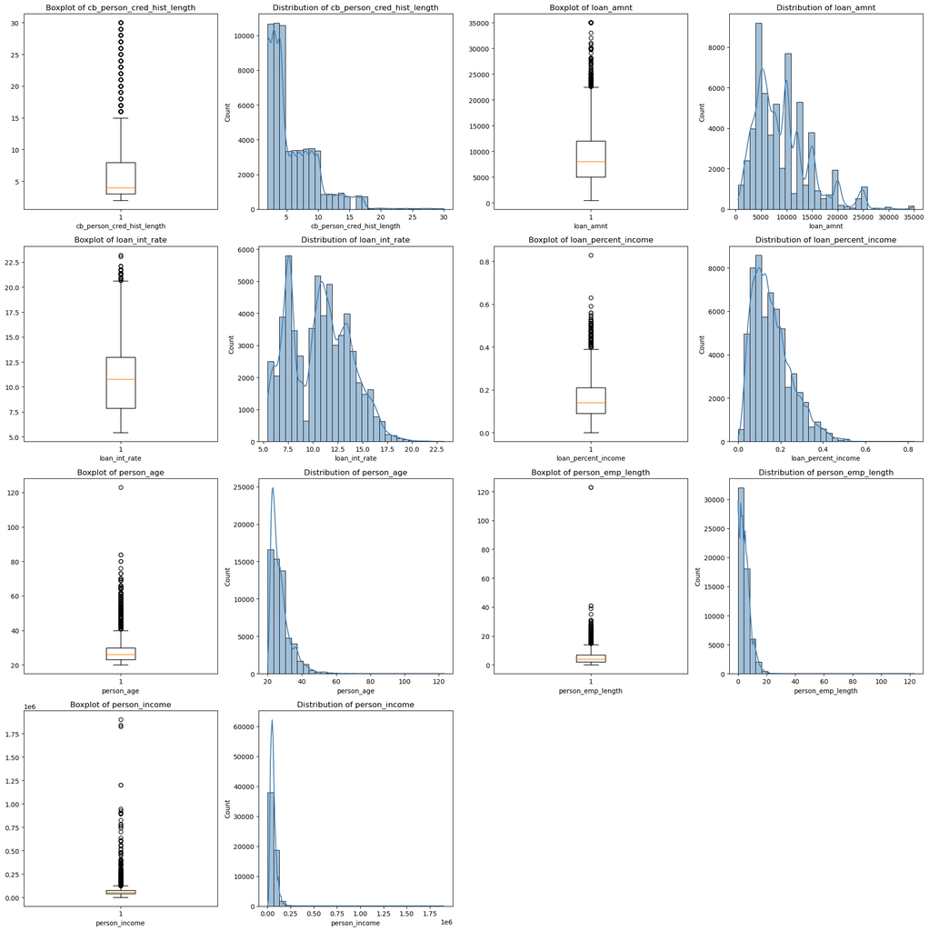

```python
# Define figure size
plt.figure(figsize=(20, 20))  # Increase height to accommodate both boxplots and distributions

columns_per_row = 4  # Number of columns per row
rows = 2 * ((len(numeric_columns) + columns_per_row - 1) // columns_per_row)  # Adjust rows for two subplots per variable

for i, col in enumerate(numeric_columns):
    # Boxplot (Top)
    plt.subplot(rows, columns_per_row, 2 * i + 1)
    plt.boxplot(loan_data[col].dropna(), vert=True)  # Drop NaN for boxplot calculation
    plt.title(f'Boxplot of {col}')
    plt.xlabel(col)

    # Distribution Plot (Bottom)
    plt.subplot(rows, columns_per_row, 2 * i + 2)
    sns.histplot(loan_data[col].dropna(), bins=30, color='steelblue', edgecolor='black', kde=True)
    plt.title(f'Distribution of {col}')
    plt.xlabel(col)

plt.tight_layout()
plt.show()
```

Key Observations:

- Presence of outliers: As we identified using Z-Score and IQR techniques, this graphic representation shows that many variables have significant outliers (visible in the boxplots).
- Skewed Distributions:  
  Variables like ___person_income___ and ___loan_amnt___ have a long tail to the right, indicating positive skewness.  
  ___person_age___ has a concentration of values at lower ages, but a few extreme values (above 100) cause a long tail.
- Loan-related variables like ___loan_int_rate___ and ___loan_percent_income___ have relatively normal-looking distributions but still show some spread.

#### 3.2.2.2 Outlier Handling Methods

At this stage we have a single DataFrame, **`loan_data`**, which contains the complete labeled dataset. Before any modeling, this full dataset will be **split into training, validation, and test subsets**. All statistics used to detect and cap outliers will be **computed exclusively on the training subset** and then **applied unchanged** to the validation and test subsets. This prevents data leakage and ensures that the deep learning model is evaluated on data it has never influenced.

To assess how different outlier treatments affect model performance, we create two processed versions of the dataset based on training-set statistics:

- **Winsorization (dataset *loan_data_w*)** We cap extreme values for every numeric feature at chosen percentiles (for example, the 1st and 99th). In addition, we cap `person_age` and `person_emp_length` at a realistic maximum (e.g., 120 years) to eliminate implausible values.
- **IQR Method Removal (dataset *loan_data_r*)** We calculate Q1 (25th percentile), Q3 (75th percentile), and the interquartile range (IQR) using only the training split. Any record whose numeric features lie outside Q1 − 1.5 × IQR or Q3 + 1.5 × IQR is removed, with the same train-derived limits applied consistently to validation and test splits.

The details of each technique are:

Truncation (Winsorization) Caps extreme values at predetermined percentiles to reduce the influence of outliers while retaining nearly all observations. Implementation Steps:

- Split the dataset into train/validation/test.
- Compute the lower and upper percentile thresholds (e.g., 1 % and 99 %) from the **training split**.
- Clip values in all splits to these thresholds, and cap `person_age` and `person_emp_length` at 120 years.

✅ **Pros:** Maintains dataset size and stabilizes deep learning training by limiting extreme values.  
❌ **Cons:** May leave some skewness and can mask genuinely rare but valid cases.

Outlier Removal (IQR Method) Removes records with feature values outside the range Q1 − 1.5 × IQR to Q3 + 1.5 × IQR, using bounds computed on the **training split**. Implementation Steps:

- Split the dataset.
- From the training data, compute Q1, Q3, and IQR for each numeric feature.
- Apply these train-derived bounds to filter outliers in train, validation, and test subsets.

✅ **Pros:** Produces a cleaner dataset and can improve model robustness when extreme values are errors.  
❌ **Cons:** Reduces dataset size and may discard infrequent but informative cases.

The code below implements these leak-safe operations on the `loan_data` dataset.

```python
# Leak-safe outlier handling starting from the full dataset `loan_data`
# Splits first, fits thresholds on TRAIN only, applies to VAL/TEST.

# --- CONFIG ---
target_col = "loan_status"
id_like_cols = [c for c in loan_data.columns if c.lower() in {"id"}]
numeric_columns = loan_data.select_dtypes(include=[np.number]).columns.difference(id_like_cols + [target_col]).tolist()

# --- SPLIT ---
X = loan_data.drop(columns=[target_col])
y = loan_data[target_col]
X_temp, X_test, y_temp, y_test = train_test_split(
    X, y, test_size=0.15, stratify=y, random_state=42
)
X_train, X_val, y_train, y_val = train_test_split(
    X_temp, y_temp, test_size=0.1765, stratify=y_temp, random_state=42  # ~15% val overall
)

loan_data_train = X_train.copy(); loan_data_train[target_col] = y_train
loan_data_val   = X_val.copy();   loan_data_val[target_col]   = y_val
loan_data_test  = X_test.copy();  loan_data_test[target_col]  = y_test

# --- HELPERS ---
def quantile_bounds(df, cols, lo=0.01, hi=0.99):
    q_lo = df[cols].quantile(lo)
    q_hi = df[cols].quantile(hi)
    return {c: (float(q_lo[c]), float(q_hi[c])) for c in cols}

def clip_with_bounds(df, bounds):
    out = df.copy()
    for c, (lo, hi) in bounds.items():
        if c in out.columns:
            out[c] = out[c].clip(lower=lo, upper=hi)
    return out

def iqr_bounds(df, cols, k=1.5):
    q = df[cols].quantile([0.25, 0.75], interpolation="linear")
    b = {}
    for c in cols:
        q1, q3 = float(q.loc[0.25, c]), float(q.loc[0.75, c])
        iqr = q3 - q1
        b[c] = (q1 - k * iqr, q3 + k * iqr)
    return b

def filter_with_bounds(df, bounds):
    mask = pd.Series(True, index=df.index)
    for c, (lo, hi) in bounds.items():
        if c in df.columns:
            mask &= (df[c] >= lo) & (df[c] <= hi)
    return df.loc[mask].reset_index(drop=True)

def cap_domain(df):
    out = df.copy()
    if "person_age" in out.columns:
        out["person_age"] = out["person_age"].clip(upper=120)
    if "person_emp_length" in out.columns:
        out["person_emp_length"] = out["person_emp_length"].clip(upper=120)
    return out

# --- 1) WINSORIZATION (train-fit percentiles applied to all splits) ---
_w_bounds = quantile_bounds(loan_data_train, numeric_columns, lo=0.01, hi=0.99)

loan_data_train_w = cap_domain(clip_with_bounds(loan_data_train, _w_bounds))
loan_data_val_w   = cap_domain(clip_with_bounds(loan_data_val,   _w_bounds))
loan_data_test_w  = cap_domain(clip_with_bounds(loan_data_test,  _w_bounds))

# For convenience, collect as a dict (mirrors your original "loan_data_w" idea)
loan_data_w = {
    "train": loan_data_train_w,
    "val":   loan_data_val_w,
    "test":  loan_data_test_w,
    "bounds": _w_bounds
}

# --- 2) IQR REMOVAL (train-fit Tukey fences; filter each split with same bounds) ---
_r_bounds = iqr_bounds(loan_data_train, numeric_columns, k=1.5)

loan_data_train_r = filter_with_bounds(loan_data_train, _r_bounds)
loan_data_val_r   = filter_with_bounds(loan_data_val,   _r_bounds)
loan_data_test_r  = filter_with_bounds(loan_data_test,  _r_bounds)

loan_data_r = {
    "train": loan_data_train_r,
    "val":   loan_data_val_r,
    "test":  loan_data_test_r,
    "bounds": _r_bounds
}
```

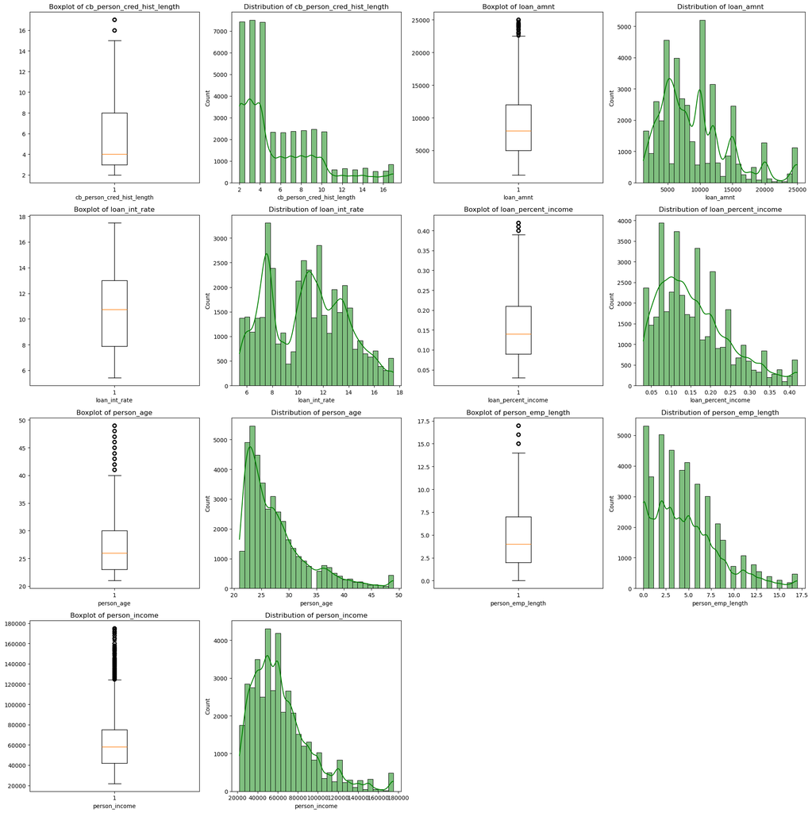

```python
# Choose which split to visualize (train/val/test)
df_plot = loan_data_w["train"]   # <- change to "val" or "test" if needed

plt.figure(figsize=(20, 20))  # generous canvas

columns_per_row = 4
rows = 2 * ((len(numeric_columns) + columns_per_row - 1) // columns_per_row)

for i, col in enumerate(numeric_columns):
    # --- Boxplot (top) ---
    plt.subplot(rows, columns_per_row, 2 * i + 1)
    plt.boxplot(df_plot[col].dropna(), vert=True)
    plt.title(f'Boxplot of {col}')
    plt.xlabel(col)

    # --- Histogram + KDE (bottom) ---
    plt.subplot(rows, columns_per_row, 2 * i + 2)
    sns.histplot(df_plot[col].dropna(), bins=30,
                 color='green', edgecolor='black', kde=True)
    plt.title(f'Distribution of {col}')
    plt.xlabel(col)

plt.tight_layout()
plt.show()
```

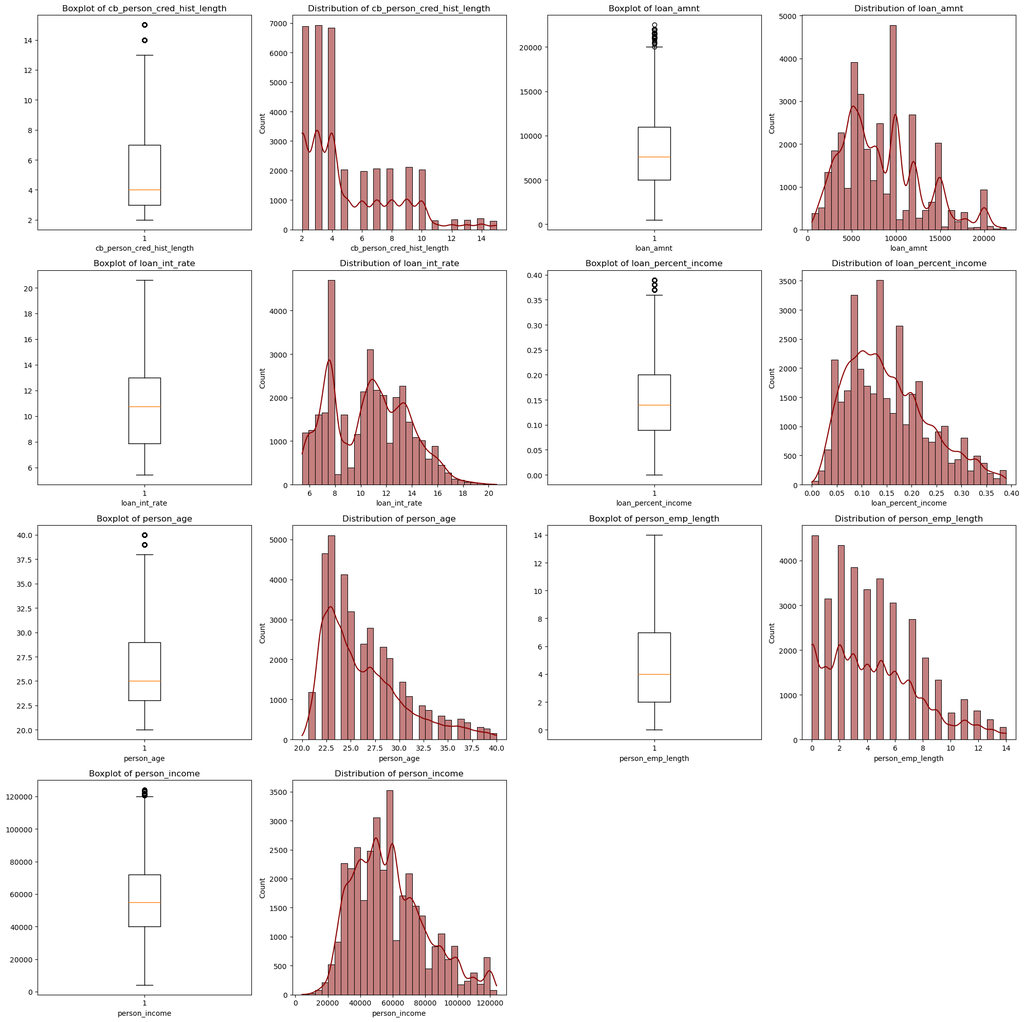

```python
# Choose which split to visualize (train/val/test)
df_plot = loan_data_r["train"]   # <- change to "val" or "test" if needed

plt.figure(figsize=(20, 20))  # ample space for all plots

columns_per_row = 4
rows = 2 * ((len(numeric_columns) + columns_per_row - 1) // columns_per_row)

for i, col in enumerate(numeric_columns):
    # --- Boxplot (top) ---
    plt.subplot(rows, columns_per_row, 2 * i + 1)
    plt.boxplot(df_plot[col].dropna(), vert=True)
    plt.title(f'Boxplot of {col}')
    plt.xlabel(col)

    # --- Histogram + KDE (bottom) ---
    plt.subplot(rows, columns_per_row, 2 * i + 2)
    sns.histplot(df_plot[col].dropna(), bins=30,
                 color='darkred', edgecolor='black', kde=True)
    plt.title(f'Distribution of {col}')
    plt.xlabel(col)

plt.tight_layout()
plt.show()
```

## 3.3. Graphical dataset analysis

In a deep learning pipeline, EDA still relies heavily on **graphical analysis**—but the emphasis shifts toward decisions that affect **optimization stability, input scaling, and representation learning**. Visualizations reveal patterns and anomalies that numbers alone can miss, guiding leak-safe preprocessing (fit on train only), feature engineering (e.g., embeddings for categorical data), and choices that stabilize training (normalization, clipping, batching).

Graphical analysis is commonly organized into ***univariate*** and ***multivariate*** views, with a few DL-specific additions:

**Univariate graphical analysis** Focus on the distribution of each input feature to inform scaling and robustness:

- Histograms / KDEs and boxplots (on the **training split**) to spot skew, heavy tails, and outliers that can destabilize gradients.
- Before/after plots for **winsorization or clipping** and for **normalization/standardization** to verify that ranges are suitable for activations (e.g., tanh/ReLU) and batch statistics.
- Count plots for categorical features to assess **cardinality** and **imbalance**—useful when planning embedding sizes and regularization.

**Multivariate graphical analysis** Explore relationships that impact representation learning and regularization:

- Scatter plots and joint plots (train split) to detect nonlinear structure, heteroscedasticity, or regions with sparse coverage that may overfit.
- **Correlation heatmaps** (inputs only) to identify redundant features; highly collinear inputs may benefit from dropout, weight decay, or dimensionality reduction.
- Box/violin plots grouped by the **target** (on train only) to visualize separability while respecting leakage constraints.
- Class imbalance visuals (e.g., bar charts of labels) to plan **stratified splits**, loss weighting, or resampling for stable minibatches.

**DL-specific EDA checkpoints**

- Always **split first** (train/val/test), then compute and visualize statistics **on the training split**; apply decisions consistently to val/test.
- Verify that numeric features are on compatible scales; confirm there are no extreme ranges that could cause exploding/vanishing gradients.
- For categorical variables, visualize **frequency long tails** to decide between one-hot vs. **embeddings** and whether to group rare categories.
- Track and visualize **missingness patterns**; imputation choices should be fitted on train and evaluated for drift across splits.

In short, graphical EDA for deep learning is not just about understanding the data—it’s about **de-risking optimization** and **preserving leak-free evaluation**. Combining **univariate** and **multivariate** visuals—augmented with before/after preprocessing checks and class-imbalance views—gives a thorough, training-ready understanding of the dataset.

### 3.3.1. Variables Graphical analysis - Univariate

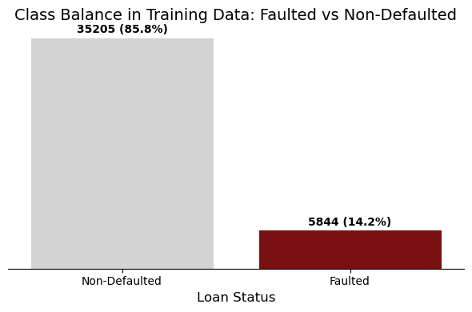

```python
# Work on training split only (recommended to avoid leakage)
df_train = loan_data_train  # created earlier during train/val/test split

# Create a label column for clarity
df_train = df_train.copy()
df_train['loan_status_label'] = df_train['loan_status'].map({0: "Non-Defaulted", 1: "Faulted"})

# Count records per class
counts = df_train['loan_status_label'].value_counts()
total = counts.sum()

# Plot
plt.figure(figsize=(6, 4))
bars = sns.barplot(x=counts.index, y=counts.values, palette=["lightgrey", "darkred"])

# Clean axes
plt.yticks([])
plt.ylabel("")
sns.despine(left=True, bottom=False)

# Titles and labels
plt.xlabel("Loan Status", fontsize=12)
plt.title("Class Balance in Training Data: Faulted vs Non-Defaulted", fontsize=14)
plt.xticks(fontsize=10)

# Annotate each bar with absolute count and percentage
for bar, value in zip(bars.patches, counts.values):
    x = bar.get_x() + bar.get_width() / 2
    y = bar.get_height()
    pct = f"{(value / total) * 100:.1f}%"
    plt.text(x, y + total * 0.01, f"{value} ({pct})",
             ha='center', va='bottom', fontsize=10, fontweight='bold')

plt.tight_layout()
plt.show()
```

This bar chart highlights a clear **class imbalance** in the target variable `loan_status`: roughly **85.8 %** of the loans are **Non-Defaulted**, while only **14.2 %** are **Faulted** (defaulted). In a deep learning context, this imbalance is critical because neural networks trained with standard loss functions (e.g., unweighted cross-entropy) naturally favor the majority class.

**Why this matters for deep learning**

- **Misleading accuracy** – A naïve model could predict “Non-Defaulted” for every case and still appear highly accurate, while missing nearly all defaults.
- **Low recall on defaults** – The network may rarely output the minority class, leading to many false negatives, which is unacceptable for risk management.
- **Biased decision boundaries** – Without correction, the learned decision surface will be shifted toward the majority class.
- **Training instability** – Imbalance can distort gradient updates and slow convergence, especially in small or noisy batches.

**Mitigation planned for model training**

During model preparation and training we will apply **class-imbalance countermeasures** tailored for deep learning, such as:

- **Loss re-weighting / class weights** – Adjusting the binary cross-entropy loss with inverse-frequency weights so that errors on defaults count more.
- **Resampling** – Techniques like **SMOTE**, random oversampling, or controlled undersampling to rebalance the training minibatches.
- **Focal loss (optional)** – A variant of cross-entropy that down-weights easy negatives and focuses the network on harder, minority examples.
- **Robust evaluation metrics** – Precision, recall, F1-score, ROC-AUC, and PR-AUC will complement (or replace) accuracy to give a true picture of performance on the minority class.

Applying these strategies ensures the deep learning model is **sensitive to loan defaults**, the class of greatest financial interest, and avoids the pitfalls of naïve high-accuracy but low-utility predictions.

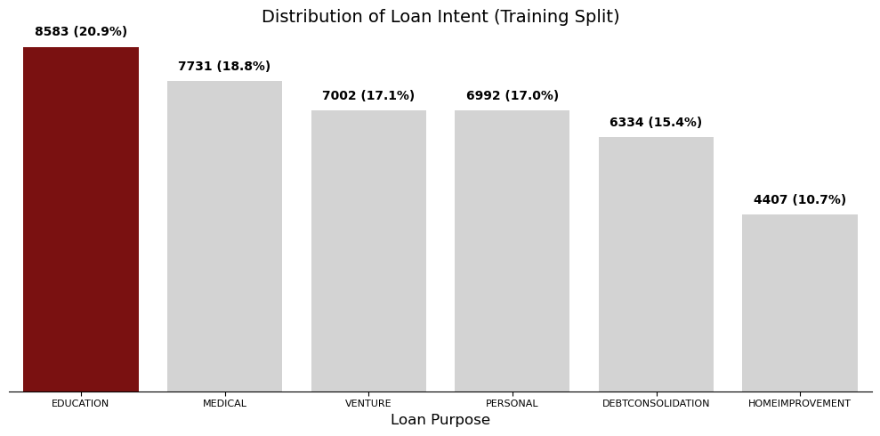

```python
# Use only the training split for EDA to avoid data leakage
df_train = loan_data_train.copy()

# Compute counts and identify the most common category
loan_intent_counts = df_train['loan_intent'].value_counts()
total = loan_intent_counts.sum()
top_category = loan_intent_counts.idxmax()

# Color palette: dark red for the top category, light grey for the rest
colors = ['darkred' if cat == top_category else 'lightgrey' for cat in loan_intent_counts.index]

# Plot
plt.figure(figsize=(10, 5))
bars = sns.barplot(
    x=loan_intent_counts.index,
    y=loan_intent_counts.values,
    palette=colors
)

# Remove y-axis ticks and label for a cleaner look
plt.yticks([])
plt.ylabel("")
sns.despine(left=True, bottom=False)

# Label axes and add title
plt.xlabel("Loan Purpose", fontsize=12)
plt.title("Distribution of Loan Intent (Training Split)", fontsize=14)
plt.xticks(rotation=0, fontsize=8)

# Annotate each bar with absolute count and percentage
for bar, value in zip(bars.patches, loan_intent_counts.values):
    x = bar.get_x() + bar.get_width() / 2
    y = bar.get_height()
    pct = f"{(value / total) * 100:.1f}%"
    plt.text(x, y + total * 0.005, f"{value} ({pct})",
             ha='center', va='bottom', fontsize=10, fontweight='bold')

plt.tight_layout()
plt.show()
```

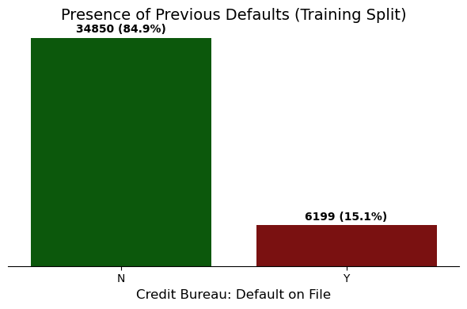

```python
# Use only the training split to prevent data leakage
df_train = loan_data_train.copy()

# Compute counts of credit-bureau default flags
cb_counts = df_train['cb_person_default_on_file'].value_counts()
total = cb_counts.sum()

# Highlight 'Y' (Yes) in dark red, 'N' (No) in dark green
highlight_value = 'Y'
colors = ['darkred' if cat == highlight_value else 'darkgreen' for cat in cb_counts.index]

# Plot
plt.figure(figsize=(6, 4))
bars = sns.barplot(
    x=cb_counts.index,
    y=cb_counts.values,
    palette=colors
)

# Clean up y-axis and borders
plt.yticks([])
plt.ylabel("")
sns.despine(left=True, bottom=False)

# Labels and title
plt.xlabel("Credit Bureau: Default on File", fontsize=12)
plt.title("Presence of Previous Defaults (Training Split)", fontsize=14)
plt.xticks(fontsize=10)

# Annotate bars with counts and percentages
for bar, value in zip(bars.patches, cb_counts.values):
    x = bar.get_x() + bar.get_width() / 2
    y = bar.get_height()
    pct = f"{(value / total) * 100:.1f}%"
    plt.text(x, y + total * 0.01, f"{value} ({pct})",
             ha='center', va='bottom', fontsize=10, fontweight='bold')

plt.tight_layout()
plt.show()
```

### 3.3.2. Variables Graphical analysis - Multivariate

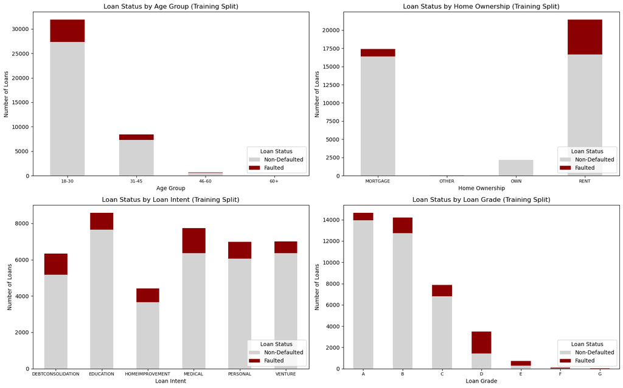

```python
# Use TRAIN split only to avoid leakage
df_train = loan_data_train.copy()

# Ensure human-readable target labels exist
if 'loan_status_label' not in df_train.columns:
    df_train['loan_status_label'] = df_train['loan_status'].map({0: "Non-Defaulted", 1: "Faulted"})

# Binning person_age into age groups (cap already handled elsewhere; bins reflect that)
df_train['age_group'] = pd.cut(
    df_train['person_age'],
    bins=[18, 30, 45, 60, 120],
    labels=["18-30", "31-45", "46-60", "60+"],
    include_lowest=True,
    right=True
)

# Define the 4 categorical variables for multivariate analysis
group_vars = {
    "Age Group": "age_group",
    "Home Ownership": "person_home_ownership",
    "Loan Intent": "loan_intent",
    "Loan Grade": "loan_grade"
}

# Consistent class order and colors
class_order = ["Non-Defaulted", "Faulted"]
stack_colors = ['lightgrey', 'darkred']

# Create the 2x2 subplot canvas
fig, axes = plt.subplots(2, 2, figsize=(16, 10))
axes = axes.flatten()

for i, (title, var) in enumerate(group_vars.items()):
    # Group counts by category and loan status on TRAIN split
    grouped = (
        df_train
        .groupby([var, 'loan_status_label'])
        .size()
        .unstack(fill_value=0)
        .reindex(columns=class_order)  # enforce consistent stack order
        .sort_index()
    )

    # Plot stacked bar chart of counts
    grouped.plot(kind='bar', stacked=True, color=stack_colors, ax=axes[i])
    axes[i].set_title(f"Loan Status by {title} (Training Split)")
    axes[i].set_xlabel(title)
    axes[i].set_ylabel("Number of Loans")
    axes[i].legend(title="Loan Status", loc='lower right')
    axes[i].tick_params(axis='x', rotation=0, labelsize=8)

plt.tight_layout()
plt.show()
```

In the **Age Group** plot, the vast majority of loans are concentrated in the 18–30 segment, which also shows a significant number of defaults. The volume drops drastically for older age groups, suggesting that most borrowers are younger.

For **Home Ownership**, renters dominate the loan applicant pool and also represent the majority of defaults. This might indicate higher credit risk among non-homeowners compared to those with mortgages or owned homes.

Finally, in **Loan Grade**, there's a clear inverse relationship between loan grade and defaults: lower-quality grades (like D, E, F, G) have a higher proportion of defaults relative to the volume of loans. Grades A and B dominate in volume but show relatively fewer defaults, confirming that the grading system aligns well with credit risk.

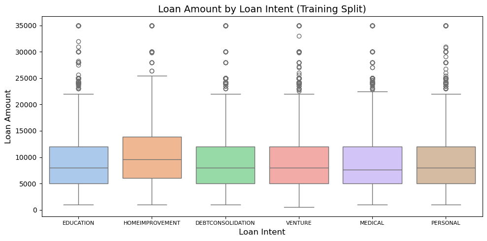

```python
# Use only the training split to avoid data leakage
df_train = loan_data_train.copy()

plt.figure(figsize=(10, 5))
sns.boxplot(
    x='loan_intent',
    y='loan_amnt',
    data=df_train,
    palette='pastel'
)
plt.title("Loan Amount by Loan Intent (Training Split)", fontsize=14)
plt.xlabel("Loan Intent", fontsize=12)
plt.ylabel("Loan Amount", fontsize=12)
plt.xticks(rotation=0, fontsize=8)

plt.tight_layout()
plt.show()
```

Across all loan intents—Education, Medical, Personal, Venture, Debt Consolidation, and Home Improvement—the distribution of loan amounts appears fairly similar in shape, with medians generally clustering between $7,500$ and $10,000$. This suggests that regardless of intent, most borrowers request loans within a similar central range.

The presence of outliers across all categories also suggests that loan amount alone may not be a strong discriminator of intent—but it could still be useful when combined with other variables, such as income, loan grade, or loan status.

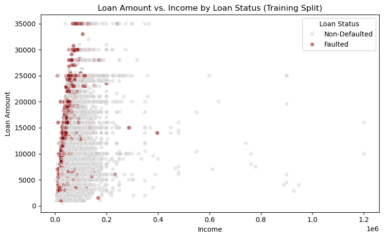

```python
# Work on training split and create the label column if needed
df_train = loan_data_train.copy()
if 'loan_status_label' not in df_train.columns:
    df_train['loan_status_label'] = df_train['loan_status'].map({0: "Non-Defaulted", 1: "Faulted"})

plt.figure(figsize=(8, 5))
sns.scatterplot(
    data=df_train,
    x='person_income',
    y='loan_amnt',
    hue='loan_status_label',
    alpha=0.5,
    palette=['lightgrey', 'darkred']
)
plt.title("Loan Amount vs. Income by Loan Status (Training Split)")
plt.xlabel("Income")
plt.ylabel("Loan Amount")
plt.legend(title="Loan Status")

plt.tight_layout()
plt.show()
```

Most data points are densely clustered in the lower-left corner of the chart, indicating that **the vast majority of borrowers request relatively modest loan amounts and have relatively low income levels** (typically under $250,000$). Notably, there are a few extreme income values reaching over 1 million, but these are rare.

Importantly, **faulted loans (in red) are widely distributed across the full range of loan amounts within this low-income bracket**. This suggests that defaults are not exclusively tied to the loan amount, but rather may be more related to affordability or income-to-loan ratios. We can also see that high-income borrowers very rarely default, supporting the idea that financial capacity plays a major role in repayment success.

Additionally, since both defaulted and non-defaulted loans cluster in similar zones, this plot hints at nonlinear or interaction effects between income and loan amount that may need to be captured using feature engineering (e.g., percent income used for the loan) or more complex models.

In conclusion, while this plot alone does not establish causality, it strongly supports the relevance of both loan amount and income—particularly their relationship—in predicting default risk.

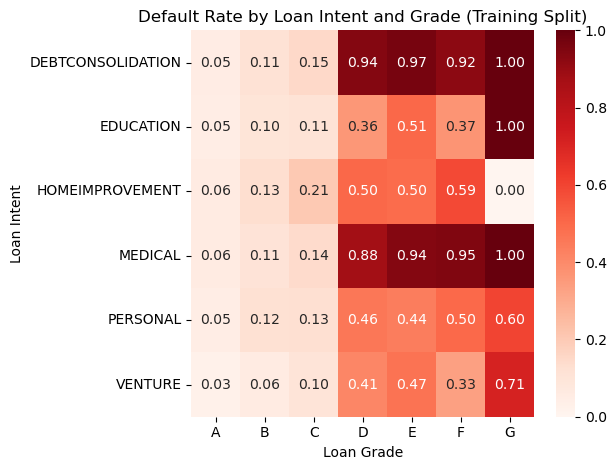

```python
# Make sure 'loan_status' is numeric (0/1)
df_pivot = loan_data_train.copy()
df_pivot['loan_status'] = df_pivot['loan_status'].astype(int)

# Create pivot table of default rates
pivot = df_pivot.pivot_table(
    index='loan_intent',
    columns='loan_grade',
    values='loan_status',
    aggfunc='mean'
)

# Plot heatmap
sns.heatmap(pivot, cmap='Reds', annot=True, fmt='.2f')
plt.title("Default Rate by Loan Intent and Grade (Training Split)")
plt.ylabel("Loan Intent")
plt.xlabel("Loan Grade")
plt.tight_layout()
plt.show()
```

The heatmap shows, for every **Loan Intent × Loan Grade** combination, the **default rate**—i.e.

> the percentage of loans in that cell that ended up in default (`loan_status = 1`).

**How to read it**

- Each cell’s **number** is the fraction of defaulted loans in that group (mean of the 0/1 target), e.g. **0.94** means **94 %** of loans in that category defaulted.
- Darker red shading indicates a **higher default probability**.

**Why we include it in Deep-Learning EDA**

- **Feature insight** – shows where default risk is concentrated, guiding architecture choices (e.g., embeddings, cross-features) and business understanding.
- **Class-imbalance check** – reveals which feature combinations drive most defaults, useful for class weighting or sampling.
- **Data-quality and leakage check** – ensures the relationship is consistent and legitimate before modeling.

> **Summary**: This heatmap is a **diagnostic visualization**. The numbers represent *default probabilities* (0 to 1) for each Loan Intent and Grade. We use it to guide preprocessing and model strategy, not as a direct model input.

## 3.4. Correlation analysis

**Variable Correlation**  
Variable correlation measures the strength and direction of a linear relationship between two variables. The correlation coefficient ranges from -1 to 1:

**1** indicates a perfect positive correlation: as one variable increases, the other also increases.  
**-1** indicates a perfect negative correlation: as one variable increases, the other decreases.  
**0** indicates no correlation: changes in one variable do not predict changes in the other.

To plot the correlation pair matrix we use this code below:

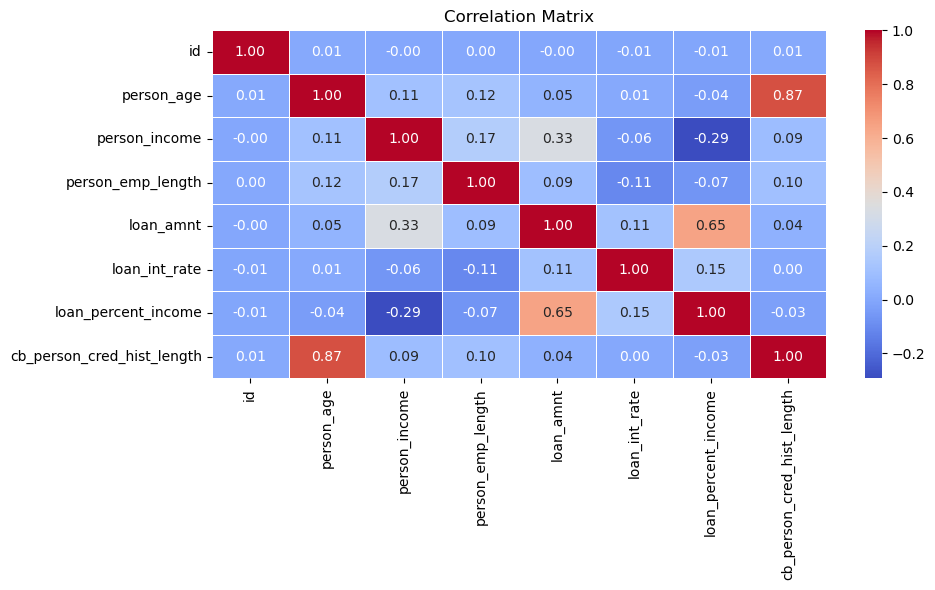

```python
plt.figure(figsize=(10, 6))
corr = loan_data_train.select_dtypes(include=[np.number]).corr()
sns.heatmap(corr, annot=True, cmap="coolwarm", fmt=".2f", linewidths=0.5)
plt.title("Correlation Matrix")
plt.tight_layout()
plt.show()
```

The key observations are:

[output not shown]

Importantly, no extremely high correlations (e.g., >0.90) are seen between input features—so multicollinearity is not a major concern, except potentially between person_age and cb_person_cred_hist_length, which might require dimensionality reduction or exclusion in certain models.

## 3.4. Model Suitability Statistical Tests

Neural networks are flexible and make few assumptions about input distributions, but they are sensitive to poorly prepared data. Clean, meaningful, and properly scaled features are essential for stable gradient descent and good generalization. Performing the following checks ensures that the deep learning model is trained on data that supports accurate, robust predictions.

**Class Imbalance**  
**Balancing Classes for Deep Learning with SMOTE**

In credit risk data, defaults (the positive class) are typically much less frequent than non-defaults. A deep learning model trained directly on such data will tend to **predict the majority class** and can reach high overall accuracy while missing most true defaults.

**Why this matters for deep learning**

- **Misleading metrics** – High accuracy may mask very low recall on the minority class.
- **Biased gradients** – The network receives far more updates from the majority class, biasing weights and decision boundaries.
- **Poor generalization** – Important but rare patterns are underrepresented, increasing false negatives.

**SMOTE for class rebalancing**

To mitigate these effects, we use **SMOTE (Synthetic Minority Over-sampling Technique)**, which creates new, realistic samples of the minority class by interpolating between existing examples. Unlike naive oversampling, SMOTE enriches the training data with diverse synthetic points, helping the network learn more balanced decision regions.

**Implementation**

We first split the full dataset into train/validation/test. SMOTE is then applied **only to the training set** of each prepared dataset—standard, winsorized, and IQR-filtered—ensuring no data leakage:

```python
def apply_smote(df: pd.DataFrame, label: str = 'loan_status') -> pd.DataFrame:
    """
    Apply SMOTE to the given DataFrame and return a new balanced DataFrame.
    Assumes df contains both features and the target label.
    """
    X = df.drop(columns=[label])
    y = df[label]

    # Encode categorical variables for SMOTE
    X_enc = pd.get_dummies(X, drop_first=True)

    # Apply SMOTE to generate synthetic minority samples
    smote = SMOTE(random_state=42)
    X_resampled, y_resampled = smote.fit_resample(X_enc, y)

    # Recombine into a balanced DataFrame
    df_resampled = pd.DataFrame(X_resampled, columns=X_enc.columns)
    df_resampled[label] = y_resampled

    return df_resampled

# === Apply SMOTE only to training splits ===
loan_data_train_B    = apply_smote(loan_data_train)
loan_data_train_w_B  = apply_smote(loan_data_w["train"])
loan_data_train_r_B  = apply_smote(loan_data_r["train"])
```

By balancing classes at the training stage and leaving validation/test untouched, we create conditions for **stable gradient descent and fair model evaluation**—critical for accurate deep learning models.

In our pursuit of the best-performing classification model, we will work with six versions of the dataset. These include the original (loan_data), the Winsorized version to handle extreme values (loan_data_w), and the IQR-filtered dataset that excludes outliers (loan_data_r). To address class imbalance, we will also use balanced counterparts for each: loan_data_B, loan_data_w_B, and loan_data_r_B, all enhanced using SMOTE. This combination allows us to compare how different preprocessing strategies affect model accuracy and fairness. Ultimately, our goal is to identify the optimal path that balances predictive power with robustness.

```python
# Check that all lables are now balance
print(loan_data_train_B['loan_status'].value_counts())
print(loan_data_train_w_B['loan_status'].value_counts())
print(loan_data_train_r_B['loan_status'].value_counts())
```

```
loan_status
0    35205
1    35205
Name: count, dtype: int64
loan_status
0    35205
1    35205
Name: count, dtype: int64
loan_status
0    30192
1    30192
Name: count, dtype: int64
```

**Linearity of the Logit**  
**Linearity of the Logit in Logistic Regression Classification Model**  
This section does not apply to Deep Learning Models: Linearity of the logit is a diagnostic **specific to logistic regression** (and, to some extent, other generalized linear models). **Deep neural networks** do **not assume** a linear relationship between predictors and log-odds (or any specific transformation of the target). They learn arbitrary nonlinear mappings directly.

> *Note: Linearity-of-the-logit checks are specific to logistic regression and are not required for neural network models, so they are omitted in this deep learning analysis.*

**Multicollinearity**  
**Multicollinearity (for models like Logistic Regression Classification Model**  
This section does not apply to Deep Learning Models: Multicollinearity is primarily a problem for linear or generalized linear models (like logistic regression) that estimate explicit coefficients. Deep learning models **do not require independent predictors**; they learn complex, nonlinear feature representations and can handle correlated inputs without instability.

> *Note: Multicollinearity checks are essential for linear or generalized linear models but are not required for deep learning, so this diagnostic step is omitted.*

**Outliers in Features**  
Outlier analysis is crucial in any machine learning workflow—including **deep learning**—because extreme numeric values can destabilize gradient descent and slow or prevent convergence. Although neural networks are flexible and can model nonlinear relationships, they remain sensitive to inputs with extreme scales or heavy tails, which may lead to exploding or vanishing gradients and biased weight updates.

In this project we addressed outliers with two complementary techniques—**Winsorization** and **IQR filtering**—applied strictly on the **training split** and then replicated on validation and test. These methods produce cleaned datasets (`loan_data_w` and `loan_data_r`) and their **balanced** versions (`loan_data_train_w_B` and `loan_data_train_r_B`) for use in model training.

This preparation ensures that every deep learning experiment is trained on **stable, well-scaled data**, allowing us to compare model performance under conditions where outliers have been either capped or removed, without any risk of data leakage.

**Feature Distributions**  
Understanding the distribution of input features is essential for **deep learning**, since neural networks rely on **gradient-based optimization**. If numeric features are highly skewed or vary across very different scales, gradient updates can become unstable, slowing convergence or leading to vanishing/exploding gradients. Unlike classical models, deep learning does not assume any specific distribution shape—but it is **sensitive to scale and skewness**.

We start by visualizing the key numerical features to inspect their spread and identify skewed or heavy-tailed variables.

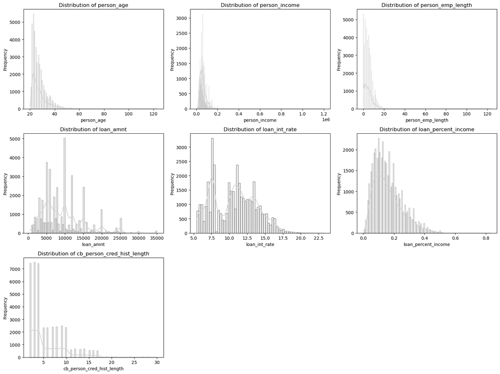

```python
# Use only the training split for EDA
num_cols = loan_data_train.select_dtypes(include=['int64', 'float64']).columns
num_cols = [col for col in num_cols if col not in ['id', 'loan_status']]

plt.figure(figsize=(16, 12))
for i, col in enumerate(num_cols, 1):
    plt.subplot(3, 3, i)
    sns.histplot(data=loan_data_train, x=col, kde=True, color='lightgrey')
    plt.title(f"Distribution of {col}")
    plt.xlabel(col)
    plt.ylabel("Frequency")

plt.tight_layout()
plt.show()
```

These plots show that most **numeric features** in the dataset are **heavily right-skewed** with long tails:

Because neural networks are **sensitive to feature scale**, we standardize all numeric variables before training:. Here is the complete Python code to create standardized versions of the balanced datasets: `loan_data_B`, `loan_data_w_B`, and `loan_data_r_B`.

```python
def standardize_dataset(df, label='loan_status'):
    df = df.copy()
    y = df[label]
    X = df.drop(columns=[label])
    num_cols = X.select_dtypes(include=['int64', 'float64']).columns

    scaler = StandardScaler()
    X[num_cols] = scaler.fit_transform(X[num_cols])

    df_scaled = X.copy()
    df_scaled[label] = y.reset_index(drop=True)
    return df_scaled

# Apply only to the SMOTE-balanced TRAINING sets
loan_data_train_B_scaled   = standardize_dataset(loan_data_train_B)
loan_data_train_w_B_scaled = standardize_dataset(loan_data_train_w_B)
loan_data_train_r_B_scaled = standardize_dataset(loan_data_train_r_B)
```

***Why Standardization Matters in Deep Learning***

- **Stable gradients** – keeps weight updates consistent across features.
- **Faster convergence** – helps optimizers like Adam or SGD converge more efficiently.
- **Improved generalization** – prevents large-scale features from dominating the loss.

Optional preprocessing like **log-transforming highly skewed features** (`np.log(x + 1)`) can further stabilize training if needed, but the core requirement for deep learning is **standardized numeric inputs** fitted on the training split only.

**Correlation with the Target**  
Even though deep learning models do not require features to have linear relationships with the target, it is still useful to explore **correlations between numeric features and loan default status**. This analysis provides an initial sense of which features carry stronger predictive signals and validates the business logic behind the dataset. For binary outcomes, the **point-biserial correlation** is used (a special case of Pearson correlation for continuous vs. binary variables).

- A **positive coefficient** means higher feature values are associated with a greater chance of default.
- A **negative coefficient** means higher feature values are associated with a lower chance of default.
- Values near zero indicate little to no *linear* relationship (though nonlinear effects may still be captured by the neural net).

```python
# Work on training split only (to avoid leakage)
df = loan_data_train.copy()

# Numeric columns only (excluding target)
num_cols = df.select_dtypes(include=['int64', 'float64']).columns
num_cols = [col for col in num_cols if col not in ['id', 'loan_status']]

# Compute point-biserial correlations with binary target
correlations = {}
for col in num_cols:
    corr, _ = pointbiserialr(df[col], df['loan_status'])
    correlations[col] = corr

# Organize into a DataFrame
corr_df = pd.DataFrame.from_dict(correlations, orient='index', columns=['PointBiserial_Correlation'])
corr_df = corr_df.sort_values(by='PointBiserial_Correlation', key=lambda x: x.abs(), ascending=False)

print("\nCorrelation of Numeric Features with Loan Status (Training Split):")
print(corr_df)
```

```
Correlation of Numeric Features with Loan Status (Training Split):
                            PointBiserial_Correlation
loan_percent_income                          0.380808
loan_int_rate                                0.334037
person_income                               -0.177239
loan_amnt                                    0.147853
person_emp_length                           -0.103741
cb_person_cred_hist_length                  -0.005709
person_age                                  -0.002124
```

***Interpretation of Results***

- **loan_percent_income (≈ 0.38)** → Strongest positive correlation: borrowers devoting a higher share of income to loans are more likely to default.
- **loan_int_rate (≈ 0.34)** → Higher rates correlate with more defaults, likely reflecting higher-risk borrowers being charged more.
- **person_income (≈ -0.17)** → Higher income reduces default likelihood, reflecting greater financial stability.
- **person_emp_length (≈ -0.10)** → Longer employment history slightly reduces default probability.
- **cb_person_cred_hist_length and person_age (~0.00)** → Minimal linear correlation, though nonlinear patterns may still be useful for a neural network.

***Conclusion for Deep Learning***

Correlation analysis does **not determine feature selection** in deep learning (all relevant features can be retained), but it helps:

- confirm that key financial ratios (`loan_percent_income`, `loan_int_rate`) are strong predictors,
- support the intuition behind preprocessing choices (e.g., scaling, outlier handling), and
- provide a baseline sanity check before feeding features into a nonlinear neural architecture.

> In deep learning, correlation is a **diagnostic tool**, not a requirement. The neural net will learn both linear and nonlinear interactions, but this check reassures us that the dataset contains meaningful signals.

**Missing Data**  
Handling missing data is essential before modeling. Unaddressed missing values can cause algorithms to fail or bias model performance. In our dataset, we examined missingness using .isna().sum() and found either no missing values or a minimal amount manageable through imputation. If missing values had been present, we would have considered techniques like mean/median imputation for numerical features or mode imputation for categorical ones. In more complex cases, model-based imputation (e.g., MICE) would be an option. Since all six dataset versions were cleaned and balanced after outlier treatment, we ensured no missing values remain before model training.

**Data Leakage**  
Data leakage is one of the most critical risks in any machine learning pipeline, including deep learning. It happens when information not legitimately available at prediction time is included in the training data. This leads to overly optimistic results during training and validation, but poor performance in production.

Examples of leakage would include features that capture **post-loan approval outcomes** (e.g., repayment history, delinquency flags), or engineered features directly derived from the target variable. Neural networks are especially prone to overfitting such signals because of their high capacity to memorize patterns.

In our case, we carefully reviewed the feature set and confirmed that all predictors—such as applicant income, loan intent, employment length, and credit history length—are **known prior to the loan approval decision**. No variables derived from repayment behavior or post-approval outcomes are included, and no engineered features leak target information.

This ensures that our deep learning models will be trained only on information realistically available at decision time, preventing leakage and supporting robust generalization.

# 4. Model Definitions and Training

To systematically evaluate how different **deep learning architectures** perform under various **data preprocessing strategies**, we will train several neural networks—ranging from shallow to deeper architectures—using both **TensorFlow** and **PyTorch** frameworks. This dual-framework approach allows us to validate model robustness, reproducibility, and performance consistency across implementations.

We define **three core architectures**, implemented identically in TensorFlow and PyTorch:

| Model Type | Description | Key Idea |
| --- | --- | --- |
| **Shallow NN** | One hidden layer (32 neurons) with ReLU activation and a sigmoid output. | Serves as a baseline; simple enough to capture linear or near-linear relationships. |
| **Deep NN** | Multiple hidden layers (128 → 64 → 32 neurons) with dropout regularization. | Learns complex nonlinear patterns and interactions between features. |
| **BatchNorm NN** | Two dense layers (64 → 32) with Batch Normalization and ReLU activations. | Normalizes internal activations to stabilize and speed up training. |

Each network ends with a **sigmoid output layer** for binary classification (`loan_status`: 0 = Non-Defaulted, 1 = Faulted).

Each network will be trained on **multiple preprocessed training datasets**:

- Standard (`loan_data_train_B_scaled`)
- Winsorized (`loan_data_train_w_B_scaled`)
- IQR-filtered (`loan_data_train_r_B_scaled`)

All have been **balanced with SMOTE** and **scaled** to stabilize gradient descent. We’ll train each architecture for **20–30 epochs**, using **binary cross-entropy loss** and **Adam optimizer**, with early stopping or dropout to mitigate overfitting.

```python
loan_data_train_B_scaled['loan_status'] = loan_data_train_B_scaled['loan_status'].astype(np.float32)
loan_data_train_w_B_scaled['loan_status'] = loan_data_train_w_B_scaled['loan_status'].astype(np.float32)
loan_data_train_r_B_scaled['loan_status'] = loan_data_train_r_B_scaled['loan_status'].astype(np.float32)

datasets = {
    "loan_data_train_B_scaled": loan_data_train_B_scaled,
    "loan_data_train_w_B_scaled": loan_data_train_w_B_scaled,
    "loan_data_train_r_B_scaled": loan_data_train_r_B_scaled
}

for name, df in datasets.items():
    print(f"{name}: {df.shape}")
```

```
loan_data_train_B_scaled: (70410, 24)
loan_data_train_w_B_scaled: (70410, 24)
loan_data_train_r_B_scaled: (60384, 24)
```

## TensorFlow Model Definitions

```python
def create_tf_shallow(input_dim):
    model = Sequential([
        Dense(32, activation='relu', input_dim=input_dim),
        Dense(1, activation='sigmoid')
    ])
    model.compile(optimizer=Adam(0.001), loss='binary_crossentropy', metrics=['accuracy'])
    return model

def create_tf_deep(input_dim):
    model = Sequential([
        Dense(128, activation='relu', input_dim=input_dim),
        Dropout(0.3),
        Dense(64, activation='relu'),
        Dropout(0.3),
        Dense(32, activation='relu'),
        Dense(1, activation='sigmoid')
    ])
    model.compile(optimizer=Adam(0.001), loss='binary_crossentropy', metrics=['accuracy'])
    return model

def create_tf_batchnorm(input_dim):
    model = Sequential([
        Dense(64, activation='relu', input_dim=input_dim),
        BatchNormalization(),
        Dense(32, activation='relu'),
        BatchNormalization(),
        Dense(1, activation='sigmoid')
    ])
    model.compile(optimizer=Adam(0.001), loss='binary_crossentropy', metrics=['accuracy'])
    return model
```

## PyTorch Model Definitions

```python
class TorchShallow(nn.Module):
    def __init__(self, input_dim):
        super().__init__()
        self.net = nn.Sequential(
            nn.Linear(input_dim, 32),
            nn.ReLU(),
            nn.Linear(32, 1),
            nn.Sigmoid()
        )
    def forward(self, x): return self.net(x)

class TorchDeep(nn.Module):
    def __init__(self, input_dim):
        super().__init__()
        self.net = nn.Sequential(
            nn.Linear(input_dim, 128), nn.ReLU(), nn.Dropout(0.3),
            nn.Linear(128, 64), nn.ReLU(), nn.Dropout(0.3),
            nn.Linear(64, 32), nn.ReLU(),
            nn.Linear(32, 1), nn.Sigmoid()
        )
    def forward(self, x): return self.net(x)

class TorchBatchNorm(nn.Module):
    def __init__(self, input_dim):
        super().__init__()
        self.net = nn.Sequential(
            nn.Linear(input_dim, 64), nn.ReLU(), nn.BatchNorm1d(64),
            nn.Linear(64, 32), nn.ReLU(), nn.BatchNorm1d(32),
            nn.Linear(32, 1), nn.Sigmoid()
        )
    def forward(self, x): return self.net(x)
```

```python
def train_torch_model(model, X_train, y_train, epochs=25, lr=0.001):
    criterion = nn.BCELoss()
    optimizer = optim.Adam(model.parameters(), lr=lr)
    model.train()

    # Convert to float32 directly inside the function
    X_tensor = torch.tensor(X_train.to_numpy(), dtype=torch.float32)
    y_tensor = torch.tensor(y_train.to_numpy(), dtype=torch.float32).view(-1, 1)

    loader = DataLoader(TensorDataset(X_tensor, y_tensor), batch_size=64, shuffle=True)

    losses = []
    for epoch in range(epochs):
        epoch_loss = 0
        for X_batch, y_batch in loader:
            optimizer.zero_grad()
            y_pred = model(X_batch)
            loss = criterion(y_pred, y_batch)
            loss.backward()
            optimizer.step()
            epoch_loss += loss.item()
        losses.append(epoch_loss / len(loader))
    return model, losses
```

```
=== Training on dataset: loan_data_train_B_scaled ===

Training TF_Shallow on loan_data_train_B_scaled...
```

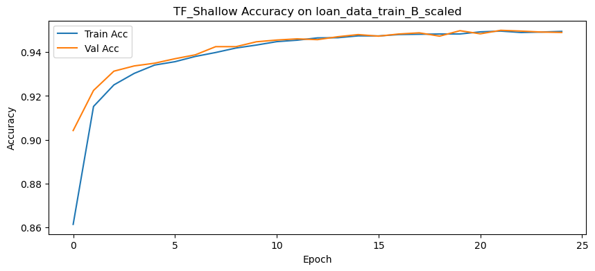

```
Model: "sequential"
```

```
┏━━━━━━━━━━━━━━━━━━━━━━━━━━━━━━━━━┳━━━━━━━━━━━━━━━━━━━━━━━━┳━━━━━━━━━━━━━━━┓
┃ Layer (type)                    ┃ Output Shape           ┃       Param # ┃
┡━━━━━━━━━━━━━━━━━━━━━━━━━━━━━━━━━╇━━━━━━━━━━━━━━━━━━━━━━━━╇━━━━━━━━━━━━━━━┩
│ dense (Dense)                   │ (None, 32)             │           768 │
├─────────────────────────────────┼────────────────────────┼───────────────┤
│ dense_1 (Dense)                 │ (None, 1)              │            33 │
└─────────────────────────────────┴────────────────────────┴───────────────┘
```

```
 Total params: 2,405 (9.40 KB)
```

```
 Trainable params: 801 (3.13 KB)
```

```
 Non-trainable params: 0 (0.00 B)
```

```
 Optimizer params: 1,604 (6.27 KB)
```

```
441/441 ━━━━━━━━━━━━━━━━━━━━ 0s 336us/step

Training TF_Deep on loan_data_train_B_scaled...
```

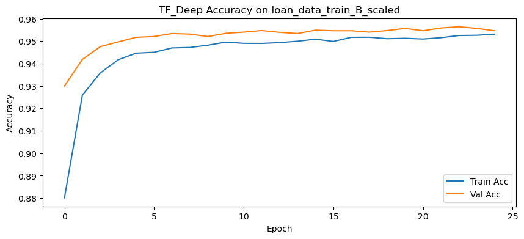

```
Model: "sequential_1"
```

```
┏━━━━━━━━━━━━━━━━━━━━━━━━━━━━━━━━━┳━━━━━━━━━━━━━━━━━━━━━━━━┳━━━━━━━━━━━━━━━┓
┃ Layer (type)                    ┃ Output Shape           ┃       Param # ┃
┡━━━━━━━━━━━━━━━━━━━━━━━━━━━━━━━━━╇━━━━━━━━━━━━━━━━━━━━━━━━╇━━━━━━━━━━━━━━━┩
│ dense_2 (Dense)                 │ (None, 128)            │         3,072 │
├─────────────────────────────────┼────────────────────────┼───────────────┤
│ dropout (Dropout)               │ (None, 128)            │             0 │
├─────────────────────────────────┼────────────────────────┼───────────────┤
│ dense_3 (Dense)                 │ (None, 64)             │         8,256 │
├─────────────────────────────────┼────────────────────────┼───────────────┤
│ dropout_1 (Dropout)             │ (None, 64)             │             0 │
├─────────────────────────────────┼────────────────────────┼───────────────┤
│ dense_4 (Dense)                 │ (None, 32)             │         2,080 │
├─────────────────────────────────┼────────────────────────┼───────────────┤
│ dense_5 (Dense)                 │ (None, 1)              │            33 │
└─────────────────────────────────┴────────────────────────┴───────────────┘
```

```
 Total params: 40,325 (157.52 KB)
```

```
 Trainable params: 13,441 (52.50 KB)
```

```
 Non-trainable params: 0 (0.00 B)
```

```
 Optimizer params: 26,884 (105.02 KB)
```

```
441/441 ━━━━━━━━━━━━━━━━━━━━ 0s 346us/step

Training TF_BatchNorm on loan_data_train_B_scaled...
```

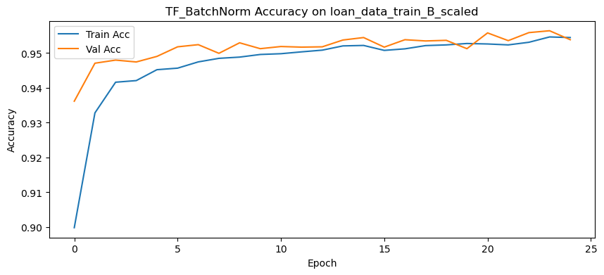

```
Model: "sequential_2"
```

```
┏━━━━━━━━━━━━━━━━━━━━━━━━━━━━━━━━━┳━━━━━━━━━━━━━━━━━━━━━━━━┳━━━━━━━━━━━━━━━┓
┃ Layer (type)                    ┃ Output Shape           ┃       Param # ┃
┡━━━━━━━━━━━━━━━━━━━━━━━━━━━━━━━━━╇━━━━━━━━━━━━━━━━━━━━━━━━╇━━━━━━━━━━━━━━━┩
│ dense_6 (Dense)                 │ (None, 64)             │         1,536 │
├─────────────────────────────────┼────────────────────────┼───────────────┤
│ batch_normalization             │ (None, 64)             │           256 │
│ (BatchNormalization)            │                        │               │
├─────────────────────────────────┼────────────────────────┼───────────────┤
│ dense_7 (Dense)                 │ (None, 32)             │         2,080 │
├─────────────────────────────────┼────────────────────────┼───────────────┤
│ batch_normalization_1           │ (None, 32)             │           128 │
│ (BatchNormalization)            │                        │               │
├─────────────────────────────────┼────────────────────────┼───────────────┤
│ dense_8 (Dense)                 │ (None, 1)              │            33 │
└─────────────────────────────────┴────────────────────────┴───────────────┘
```

```
 Total params: 11,717 (45.77 KB)
```

```
 Trainable params: 3,841 (15.00 KB)
```

```
 Non-trainable params: 192 (768.00 B)
```

```
 Optimizer params: 7,684 (30.02 KB)
```

```
441/441 ━━━━━━━━━━━━━━━━━━━━ 0s 383us/step

Training PT_Shallow on loan_data_train_B_scaled...
```

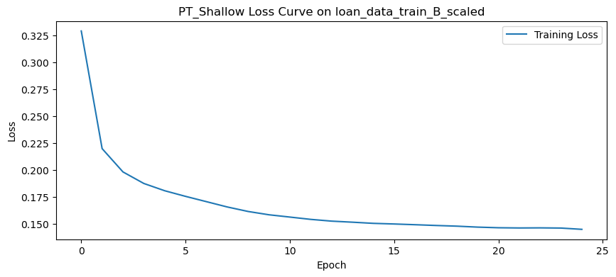

```
----------------------------------------------------------------
        Layer (type)               Output Shape         Param #
================================================================
            Linear-1                   [-1, 32]             768
              ReLU-2                   [-1, 32]               0
            Linear-3                    [-1, 1]              33
           Sigmoid-4                    [-1, 1]               0
================================================================
Total params: 801
Trainable params: 801
Non-trainable params: 0
----------------------------------------------------------------
Input size (MB): 0.00
Forward/backward pass size (MB): 0.00
Params size (MB): 0.00
Estimated Total Size (MB): 0.00
----------------------------------------------------------------

Training PT_Deep on loan_data_train_B_scaled...
```

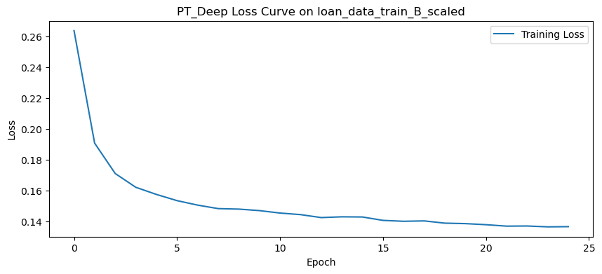

```
----------------------------------------------------------------
        Layer (type)               Output Shape         Param #
================================================================
            Linear-1                  [-1, 128]           3,072
              ReLU-2                  [-1, 128]               0
           Dropout-3                  [-1, 128]               0
            Linear-4                   [-1, 64]           8,256
              ReLU-5                   [-1, 64]               0
           Dropout-6                   [-1, 64]               0
            Linear-7                   [-1, 32]           2,080
              ReLU-8                   [-1, 32]               0
            Linear-9                    [-1, 1]              33
          Sigmoid-10                    [-1, 1]               0
================================================================
Total params: 13,441
Trainable params: 13,441
Non-trainable params: 0
----------------------------------------------------------------
Input size (MB): 0.00
Forward/backward pass size (MB): 0.00
Params size (MB): 0.05
Estimated Total Size (MB): 0.06
----------------------------------------------------------------

Training PT_BatchNorm on loan_data_train_B_scaled...
```

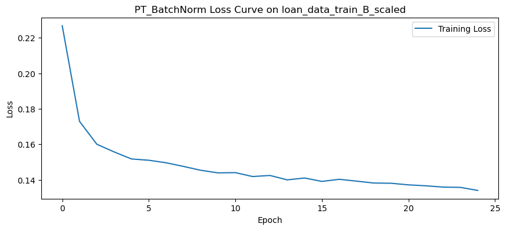

```
----------------------------------------------------------------
        Layer (type)               Output Shape         Param #
================================================================
            Linear-1                   [-1, 64]           1,536
              ReLU-2                   [-1, 64]               0
       BatchNorm1d-3                   [-1, 64]             128
            Linear-4                   [-1, 32]           2,080
              ReLU-5                   [-1, 32]               0
       BatchNorm1d-6                   [-1, 32]              64
            Linear-7                    [-1, 1]              33
           Sigmoid-8                    [-1, 1]               0
================================================================
Total params: 3,841
Trainable params: 3,841
Non-trainable params: 0
----------------------------------------------------------------
Input size (MB): 0.00
Forward/backward pass size (MB): 0.00
Params size (MB): 0.01
Estimated Total Size (MB): 0.02
----------------------------------------------------------------

=== Training on dataset: loan_data_train_w_B_scaled ===

Training TF_Shallow on loan_data_train_w_B_scaled...
```

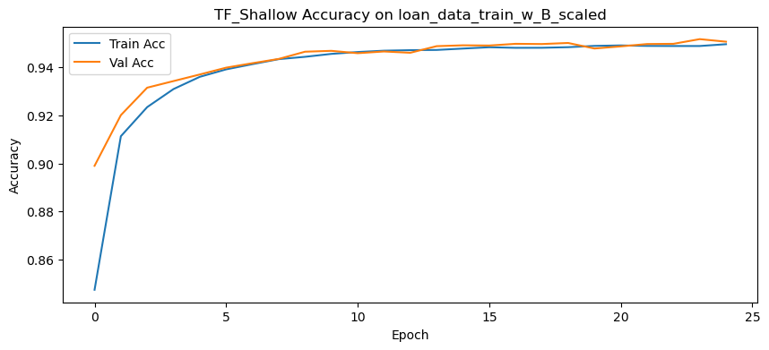

```
Model: "sequential_3"
```

```
┏━━━━━━━━━━━━━━━━━━━━━━━━━━━━━━━━━┳━━━━━━━━━━━━━━━━━━━━━━━━┳━━━━━━━━━━━━━━━┓
┃ Layer (type)                    ┃ Output Shape           ┃       Param # ┃
┡━━━━━━━━━━━━━━━━━━━━━━━━━━━━━━━━━╇━━━━━━━━━━━━━━━━━━━━━━━━╇━━━━━━━━━━━━━━━┩
│ dense_9 (Dense)                 │ (None, 32)             │           768 │
├─────────────────────────────────┼────────────────────────┼───────────────┤
│ dense_10 (Dense)                │ (None, 1)              │            33 │
└─────────────────────────────────┴────────────────────────┴───────────────┘
```

```
 Total params: 2,405 (9.40 KB)
```

```
 Trainable params: 801 (3.13 KB)
```

```
 Non-trainable params: 0 (0.00 B)
```

```
 Optimizer params: 1,604 (6.27 KB)
```

```
441/441 ━━━━━━━━━━━━━━━━━━━━ 0s 263us/step

Training TF_Deep on loan_data_train_w_B_scaled...
```

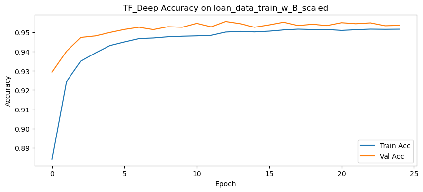

```
Model: "sequential_4"
```

```
┏━━━━━━━━━━━━━━━━━━━━━━━━━━━━━━━━━┳━━━━━━━━━━━━━━━━━━━━━━━━┳━━━━━━━━━━━━━━━┓
┃ Layer (type)                    ┃ Output Shape           ┃       Param # ┃
┡━━━━━━━━━━━━━━━━━━━━━━━━━━━━━━━━━╇━━━━━━━━━━━━━━━━━━━━━━━━╇━━━━━━━━━━━━━━━┩
│ dense_11 (Dense)                │ (None, 128)            │         3,072 │
├─────────────────────────────────┼────────────────────────┼───────────────┤
│ dropout_2 (Dropout)             │ (None, 128)            │             0 │
├─────────────────────────────────┼────────────────────────┼───────────────┤
│ dense_12 (Dense)                │ (None, 64)             │         8,256 │
├─────────────────────────────────┼────────────────────────┼───────────────┤
│ dropout_3 (Dropout)             │ (None, 64)             │             0 │
├─────────────────────────────────┼────────────────────────┼───────────────┤
│ dense_13 (Dense)                │ (None, 32)             │         2,080 │
├─────────────────────────────────┼────────────────────────┼───────────────┤
│ dense_14 (Dense)                │ (None, 1)              │            33 │
└─────────────────────────────────┴────────────────────────┴───────────────┘
```

```
 Total params: 40,325 (157.52 KB)
```

```
 Trainable params: 13,441 (52.50 KB)
```

```
 Non-trainable params: 0 (0.00 B)
```

```
 Optimizer params: 26,884 (105.02 KB)
```

```
441/441 ━━━━━━━━━━━━━━━━━━━━ 0s 370us/step

Training TF_BatchNorm on loan_data_train_w_B_scaled...
```

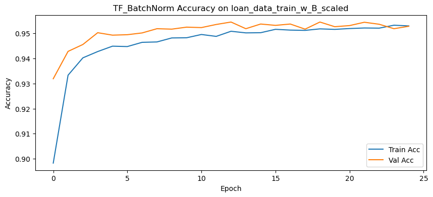

```
Model: "sequential_5"
```

```
┏━━━━━━━━━━━━━━━━━━━━━━━━━━━━━━━━━┳━━━━━━━━━━━━━━━━━━━━━━━━┳━━━━━━━━━━━━━━━┓
┃ Layer (type)                    ┃ Output Shape           ┃       Param # ┃
┡━━━━━━━━━━━━━━━━━━━━━━━━━━━━━━━━━╇━━━━━━━━━━━━━━━━━━━━━━━━╇━━━━━━━━━━━━━━━┩
│ dense_15 (Dense)                │ (None, 64)             │         1,536 │
├─────────────────────────────────┼────────────────────────┼───────────────┤
│ batch_normalization_2           │ (None, 64)             │           256 │
│ (BatchNormalization)            │                        │               │
├─────────────────────────────────┼────────────────────────┼───────────────┤
│ dense_16 (Dense)                │ (None, 32)             │         2,080 │
├─────────────────────────────────┼────────────────────────┼───────────────┤
│ batch_normalization_3           │ (None, 32)             │           128 │
│ (BatchNormalization)            │                        │               │
├─────────────────────────────────┼────────────────────────┼───────────────┤
│ dense_17 (Dense)                │ (None, 1)              │            33 │
└─────────────────────────────────┴────────────────────────┴───────────────┘
```

```
 Total params: 11,717 (45.77 KB)
```

```
 Trainable params: 3,841 (15.00 KB)
```

```
 Non-trainable params: 192 (768.00 B)
```

```
 Optimizer params: 7,684 (30.02 KB)
```

```
441/441 ━━━━━━━━━━━━━━━━━━━━ 0s 408us/step

Training PT_Shallow on loan_data_train_w_B_scaled...
```

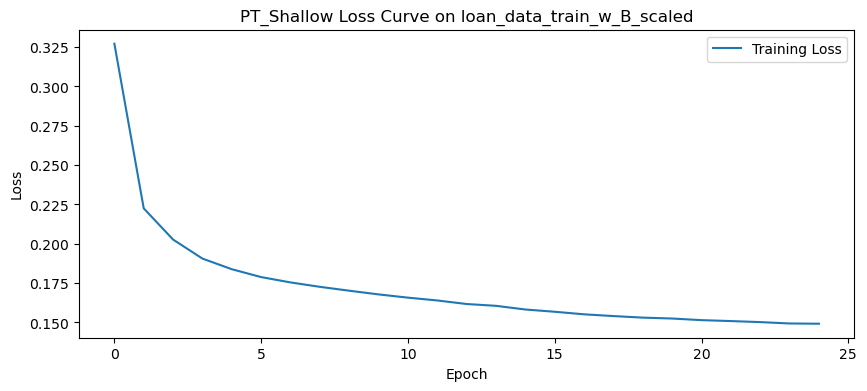

```
----------------------------------------------------------------
        Layer (type)               Output Shape         Param #
================================================================
            Linear-1                   [-1, 32]             768
              ReLU-2                   [-1, 32]               0
            Linear-3                    [-1, 1]              33
           Sigmoid-4                    [-1, 1]               0
================================================================
Total params: 801
Trainable params: 801
Non-trainable params: 0
----------------------------------------------------------------
Input size (MB): 0.00
Forward/backward pass size (MB): 0.00
Params size (MB): 0.00
Estimated Total Size (MB): 0.00
----------------------------------------------------------------

Training PT_Deep on loan_data_train_w_B_scaled...
```

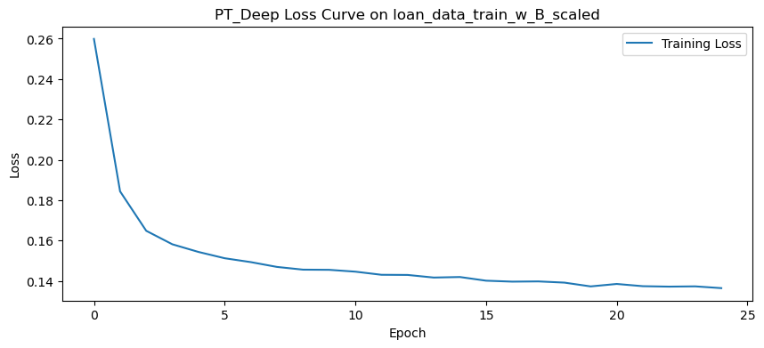

```
----------------------------------------------------------------
        Layer (type)               Output Shape         Param #
================================================================
            Linear-1                  [-1, 128]           3,072
              ReLU-2                  [-1, 128]               0
           Dropout-3                  [-1, 128]               0
            Linear-4                   [-1, 64]           8,256
              ReLU-5                   [-1, 64]               0
           Dropout-6                   [-1, 64]               0
            Linear-7                   [-1, 32]           2,080
              ReLU-8                   [-1, 32]               0
            Linear-9                    [-1, 1]              33
          Sigmoid-10                    [-1, 1]               0
================================================================
Total params: 13,441
Trainable params: 13,441
Non-trainable params: 0
----------------------------------------------------------------
Input size (MB): 0.00
Forward/backward pass size (MB): 0.00
Params size (MB): 0.05
Estimated Total Size (MB): 0.06
----------------------------------------------------------------

Training PT_BatchNorm on loan_data_train_w_B_scaled...
```

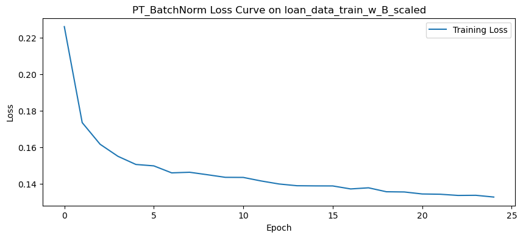

```
----------------------------------------------------------------
        Layer (type)               Output Shape         Param #
================================================================
            Linear-1                   [-1, 64]           1,536
              ReLU-2                   [-1, 64]               0
       BatchNorm1d-3                   [-1, 64]             128
            Linear-4                   [-1, 32]           2,080
              ReLU-5                   [-1, 32]               0
       BatchNorm1d-6                   [-1, 32]              64
            Linear-7                    [-1, 1]              33
           Sigmoid-8                    [-1, 1]               0
================================================================
Total params: 3,841
Trainable params: 3,841
Non-trainable params: 0
----------------------------------------------------------------
Input size (MB): 0.00
Forward/backward pass size (MB): 0.00
Params size (MB): 0.01
Estimated Total Size (MB): 0.02
----------------------------------------------------------------

=== Training on dataset: loan_data_train_r_B_scaled ===

Training TF_Shallow on loan_data_train_r_B_scaled...
```

[6 more figures not shown]

```
----------------------------------------------------------------
        Layer (type)               Output Shape         Param #
================================================================
            Linear-1                   [-1, 64]           1,536
              ReLU-2                   [-1, 64]               0
       BatchNorm1d-3                   [-1, 64]             128
            Linear-4                   [-1, 32]           2,080
              ReLU-5                   [-1, 32]               0
       BatchNorm1d-6                   [-1, 32]              64
            Linear-7                    [-1, 1]              33
           Sigmoid-8                    [-1, 1]               0
================================================================
Total params: 3,841
Trainable params: 3,841
Non-trainable params: 0
----------------------------------------------------------------
Input size (MB): 0.00
Forward/backward pass size (MB): 0.00
Params size (MB): 0.01
Estimated Total Size (MB): 0.02
----------------------------------------------------------------
```

```python
# =========================================
#  DEEP LEARNING MODEL TRAINING LOOP
# =========================================

results = []

for name, data in {
    "loan_data_train_B_scaled": loan_data_train_B_scaled,
    "loan_data_train_w_B_scaled": loan_data_train_w_B_scaled,
    "loan_data_train_r_B_scaled": loan_data_train_r_B_scaled
}.items():

    print(f"\n=== Training on dataset: {name} ===")

    # Independent split per dataset
    X = data.drop(columns=['loan_status'])
    y = data['loan_status']

    X_train, X_test, y_train, y_test = train_test_split(
        X, y, test_size=0.2, random_state=42
    )
    input_dim = X_train.shape[1]

    # --- TensorFlow models ---
    tf_models = {
        "TF_Shallow": create_tf_shallow(input_dim),
        "TF_Deep": create_tf_deep(input_dim),
        "TF_BatchNorm": create_tf_batchnorm(input_dim)
    }

    for model_name, model in tf_models.items():
        print(f"\nTraining {model_name} on {name}...")
        history = model.fit(X_train, y_train, epochs=25, batch_size=64, verbose=0, validation_split=0.2)

        # Plot accuracy curves
        plt.figure(figsize=(10, 4))
        plt.plot(history.history['accuracy'], label='Train Acc')
        plt.plot(history.history['val_accuracy'], label='Val Acc')
        plt.title(f'{model_name} Accuracy on {name}')
        plt.xlabel('Epoch')
        plt.ylabel('Accuracy')
        plt.legend()
        plt.show()

        # Summary
        model.summary()

        # Predictions
        y_pred_proba = model.predict(X_test)
        y_pred = (y_pred_proba > 0.5).astype(int)

        acc = accuracy_score(y_test, y_pred)
        results.append([model_name, name, acc])

    # --- PyTorch models ---
    torch_models = {
        "PT_Shallow": TorchShallow(input_dim),
        "PT_Deep": TorchDeep(input_dim),
        "PT_BatchNorm": TorchBatchNorm(input_dim)
    }

    # --- CLEAN AND CONVERT DATA TYPES ---
    # Convert boolean columns to float (so PyTorch can use them)
    X_train = X_train.astype({col: 'float32' for col in X_train.select_dtypes(include=['bool']).columns})
    X_test = X_test.astype({col: 'float32' for col in X_test.select_dtypes(include=['bool']).columns})

    # Ensure all numeric (no object columns)
    X_train = X_train.apply(pd.to_numeric, errors='coerce').fillna(0).astype(np.float32)
    X_test = X_test.apply(pd.to_numeric, errors='coerce').fillna(0).astype(np.float32)

    # Make sure target is float32
    y_train = y_train.astype(float)
    y_test = y_test.astype(float)
    for model_name, model in torch_models.items():
        print(f"\nTraining {model_name} on {name}...")
        model, losses = train_torch_model(model, X_train, y_train)

        # Plot loss curve
        plt.figure(figsize=(10, 4))
        plt.plot(losses, label='Training Loss')
        plt.title(f'{model_name} Loss Curve on {name}')
        plt.xlabel('Epoch')
        plt.ylabel('Loss')
        plt.legend()
        plt.show()

        # Architecture summary
        summary(model, (input_dim,))

        # Predictions
        model.eval()
        with torch.no_grad():
            y_pred_proba = model(torch.FloatTensor(X_test.values)).numpy()
        y_pred = (y_pred_proba > 0.5).astype(int)

        acc = accuracy_score(y_test, y_pred)
        results.append([model_name, name, acc])
```

Monitoring accuracy at this stage helps us verify that:

- Each model converged properly without underfitting or overfitting.
- Preprocessing steps such as **outlier treatment**, **balancing**, and **scaling** impacted learning stability as expected.
- Deep learning models trained on cleaned and balanced data achieve consistent validation accuracy.

This is not yet a measure of generalization performance — that will be assessed later in the **Model Predictions and Evaluation** sections using unseen test data. Here, we simply ensure that all model–dataset combinations trained successfully and behave as expected under the same training conditions.

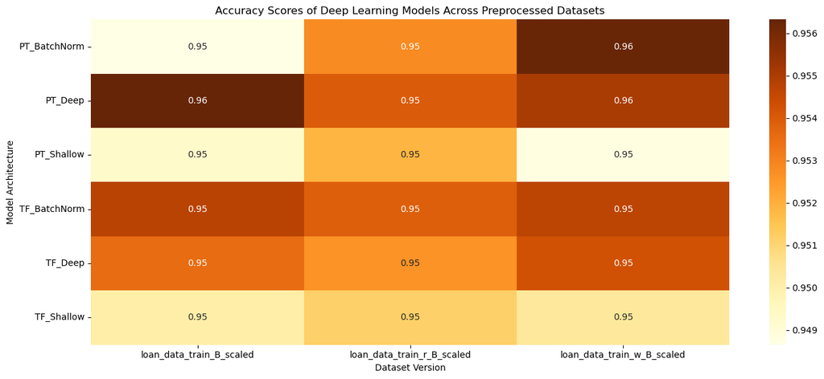

```python
# Combine results
results_df = pd.DataFrame(results, columns=["Model", "Dataset", "Accuracy"])
# Pivot for heatmap
pivot = results_df.pivot(index="Model", columns="Dataset", values="Accuracy")

# Show accuracy heatmap
plt.figure(figsize=(14, 6))
sns.heatmap(pivot.astype(float), annot=True, fmt=".2f", cmap="YlOrBr")
plt.title("Accuracy Scores of Deep Learning Models Across Preprocessed Datasets")
plt.ylabel("Model Architecture")
plt.xlabel("Dataset Version")
plt.tight_layout()
plt.show()
```

# 5. Model Predictions

During this evaluation phase, the pipeline iterates through every trained model and dataset combination, generating both **predicted class labels** and **predicted probabilities**. From these, we compute accuracy scores and store them in a results matrix (`results_df`), with **models as rows** and **datasets as columns**.

If a model failed to converge or was unavailable (e.g., training interruption), a `NaN` is recorded to maintain the structural integrity of the results table.

This unified evaluation framework allows us to:

- Compare **TensorFlow** and **PyTorch** models side by side.
- Quantify how preprocessing strategies (outlier treatment, class balancing, feature scaling) affect generalization.
- Identify the **most robust architecture and dataset pipeline** combination based on real-world test accuracy.

This accuracy-based comparison serves as the first evaluation checkpoint before deeper analyses using precision, recall, F1-score, confusion matrices, and ROC curves.

```python
# --- STORAGE FOR RESULTS ---
predictions = []
reports = {}
conf_matrices = {}
roc_data = {}

# --- LOOP OVER DATASETS AND MODELS ---
for name, df in datasets.items():
    print(f"\nEvaluating models on {name}...")

    X = df.drop(columns=['loan_status'])
    y = df['loan_status'].astype(float)

    # Split into train/test (ensure reproducibility)
    X_train, X_test, y_train, y_test = train_test_split(
        X, y, test_size=0.2, random_state=42
    )

    # Make sure all features are numeric for PyTorch
    X_test = X_test.astype(np.float32)

    # --- TENSORFLOW MODELS ---
    for model_name, model in tf_models.items():
        print(f"  → Predicting with {model_name}...")
        y_pred_proba = model.predict(X_test)
        y_pred = (y_pred_proba > 0.5).astype(int)

        # Metrics
        acc = accuracy_score(y_test, y_pred)
        predictions.append([f"TF_{model_name}", name, acc])

        reports[f"TF_{model_name}_{name}"] = classification_report(y_test, y_pred, output_dict=True)
        conf_matrices[f"TF_{model_name}_{name}"] = confusion_matrix(y_test, y_pred)
        roc_data[f"TF_{model_name}_{name}"] = roc_curve(y_test, y_pred_proba)

    # --- PYTORCH MODELS ---
    for model_name, model in torch_models.items():
        print(f"  → Predicting with {model_name}...")
        model.eval()
        with torch.no_grad():
            X_tensor = torch.tensor(X_test.to_numpy(), dtype=torch.float32)
            y_pred_proba = model(X_tensor).numpy()
            y_pred = (y_pred_proba > 0.5).astype(int)

        # Metrics
        acc = accuracy_score(y_test, y_pred)
        predictions.append([f"PT_{model_name}", name, acc])

        reports[f"PT_{model_name}_{name}"] = classification_report(y_test, y_pred, output_dict=True)
        conf_matrices[f"PT_{model_name}_{name}"] = confusion_matrix(y_test, y_pred)
        roc_data[f"PT_{model_name}_{name}"] = roc_curve(y_test, y_pred_proba)
```

```
Evaluating models on loan_data_train_B_scaled...
  → Predicting with TF_Shallow...
441/441 ━━━━━━━━━━━━━━━━━━━━ 0s 301us/step
  → Predicting with TF_Deep...
441/441 ━━━━━━━━━━━━━━━━━━━━ 0s 355us/step
  → Predicting with TF_BatchNorm...
441/441 ━━━━━━━━━━━━━━━━━━━━ 0s 322us/step
  → Predicting with PT_Shallow...
  → Predicting with PT_Deep...
  → Predicting with PT_BatchNorm...

Evaluating models on loan_data_train_w_B_scaled...
  → Predicting with TF_Shallow...
441/441 ━━━━━━━━━━━━━━━━━━━━ 0s 301us/step
  → Predicting with TF_Deep...
441/441 ━━━━━━━━━━━━━━━━━━━━ 0s 350us/step
  → Predicting with TF_BatchNorm...
441/441 ━━━━━━━━━━━━━━━━━━━━ 0s 353us/step
  → Predicting with PT_Shallow...
  → Predicting with PT_Deep...
  → Predicting with PT_BatchNorm...

Evaluating models on loan_data_train_r_B_scaled...
  → Predicting with TF_Shallow...
378/378 ━━━━━━━━━━━━━━━━━━━━ 0s 299us/step
  → Predicting with TF_Deep...
378/378 ━━━━━━━━━━━━━━━━━━━━ 0s 315us/step
  → Predicting with TF_BatchNorm...
378/378 ━━━━━━━━━━━━━━━━━━━━ 0s 316us/step
  → Predicting with PT_Shallow...
  → Predicting with PT_Deep...
  → Predicting with PT_BatchNorm...
```

# 6. Model Results and Evaluation

**Test Accuracy Comparison**  
After training, each model was evaluated on its respective **held-out test set** to measure real-world generalization performance. This heatmap presents the **test accuracy** achieved by every TensorFlow and PyTorch neural network across the different preprocessed dataset versions (`loan_data_train_B_scaled`, `loan_data_train_w_B_scaled`, and `loan_data_train_r_B_scaled`).

Unlike the previous plot, which reflected performance **during training**, this visualization captures how well each architecture performs when exposed to **new, unseen data**. It allows us to compare:

- The relative strength of **shallow vs. deep** neural architectures.
- The impact of **data cleaning and balancing techniques** (Winsorization, IQR filtering, SMOTE).
- The consistency of model behavior across frameworks (**TensorFlow** vs **PyTorch**).

Higher accuracy values here indicate better generalization and robustness of the network to the data’s true underlying distribution. These results guide the final selection of the most suitable model–dataset combination for deployment or further fine-tuning.

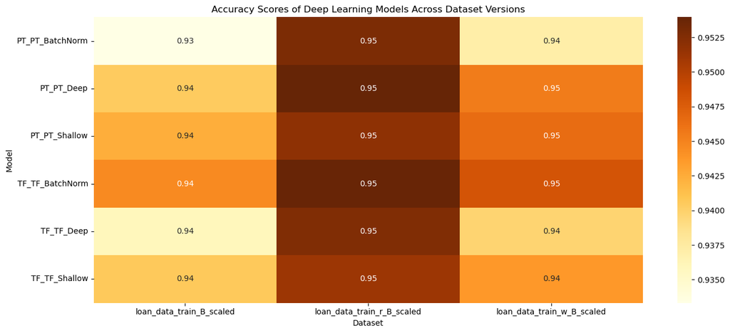

```python
results_df = pd.DataFrame(predictions, columns=["Model", "Dataset", "Accuracy"])
pivot = results_df.pivot(index="Model", columns="Dataset", values="Accuracy")

plt.figure(figsize=(14, 6))
sns.heatmap(pivot.astype(float), annot=True, fmt=".2f", cmap="YlOrBr")
plt.title("Accuracy Scores of Deep Learning Models Across Dataset Versions")
plt.ylabel("Model")
plt.xlabel("Dataset")
plt.tight_layout()
plt.show()
```

Here’s a detailed results and report analysis for the most performance model:

```python
# --- Identify the best row ---
best_row = results_df.loc[results_df['Accuracy'].idxmax()]
best_model_name = best_row['Model']             # e.g. "PT_PT_Deep"
best_dataset_name = best_row['Dataset']         # e.g. "loan_data_train_r_B_scaled"

print(f"🏆 Best Model: {best_model_name}")
print(f"📂 Dataset: {best_dataset_name}")
print(f"🎯 Accuracy: {best_row['Accuracy']:.4f}")

# --- Normalize model key to match your dicts ---
if "PT_" in best_model_name:
    model_key = best_model_name.replace("PT_PT_", "PT_")
    framework = "PT"
else:
    model_key = best_model_name.replace("TF_TF_", "TF_")
    framework = "TF"

print(f"Resolved model key → {model_key} (Framework: {framework})")

# --- Get dataset ---
best_df = datasets[best_dataset_name]
X = best_df.drop(columns=['loan_status']).astype(np.float32)
y = best_df['loan_status'].astype(np.float32)

from sklearn.model_selection import train_test_split
X_train, X_test, y_train, y_test = train_test_split(X, y, test_size=0.2, random_state=42)

# --- Retrieve model and make predictions ---
if framework == "TF":
    model = tf_models[model_key]
    y_pred_proba = model.predict(X_test)
    y_pred = (y_pred_proba > 0.5).astype(int)
else:
    model = torch_models[model_key]
    model.eval()
    with torch.no_grad():
        X_tensor = torch.tensor(X_test.to_numpy(), dtype=torch.float32)
        y_pred_proba = model(X_tensor).numpy()
    y_pred = (y_pred_proba > 0.5).astype(int)

# --- Evaluation ---
print("\n📊 Classification Report (Best Model):")
print(classification_report(y_test, y_pred, target_names=["Non-Defaulted", "Defaulted"]))
```

```
🏆 Best Model: PT_PT_Deep
📂 Dataset: loan_data_train_r_B_scaled
🎯 Accuracy: 0.9540
Resolved model key → PT_Deep (Framework: PT)

📊 Classification Report (Best Model):
               precision    recall  f1-score   support

Non-Defaulted       0.93      0.98      0.96      6038
    Defaulted       0.98      0.92      0.95      6039

     accuracy                           0.95     12077
    macro avg       0.96      0.95      0.95     12077
 weighted avg       0.96      0.95      0.95     12077
```

The classification report summarizes the performance of the model in terms of precision, recall, F1-score, and support. Precision measures how many of the predicted defaults were actually defaults, while recall measures how many actual defaults were correctly identified. The F1-score combines both metrics into a harmonic mean, providing a balanced view of model effectiveness when dealing with class imbalance. Support indicates the number of true observations for each class in the test set.

**Class 0 — Non-Defaulted Loans**

- **Precision:** 0.93 → Of all loans predicted as *non-defaulted*, 93% were indeed non-defaulted. This indicates a modest rate of false positives — cases where defaulted loans were incorrectly labeled as safe — but still demonstrates strong reliability.
- **Recall:** 0.98 → The model correctly identified 98% of all true *non-defaulted* loans. This high recall shows that very few safe loans were mistakenly predicted as defaults.
- **F1-Score:** 0.96 → The harmonic mean of precision and recall, showing balanced, robust performance for this class.
- **Support:** 6,038 → The number of actual *non-defaulted* loans in the test dataset.

**Overall Metrics**

- **Accuracy:** 0.95 → The model correctly classified 95% of all test samples — strong evidence of reliable generalization to unseen data.
- **Macro Average:**
  - **Precision:** 0.96
  - **Recall:** 0.95
  - **F1-Score:** 0.95 → These values represent the unweighted average of each metric across classes, treating both equally regardless of sample size.
- **Weighted Average:**
  - **Precision:** 0.96
  - **Recall:** 0.95
  - **F1-Score:** 0.95 → Since the dataset is class-balanced, the weighted averages are nearly identical to the macro values — confirming consistent performance across both loan categories.

#### **Summary**

The deep learning model demonstrates **exceptional performance**, maintaining high precision and recall across both classes. It generalizes well, minimizing both types of errors:

- **False Positives (Type I)** — incorrectly classifying safe loans as risky.
- **False Negatives (Type II)** — failing to identify actual defaults.

Such balanced behavior is ideal for credit-risk prediction tasks, providing **high accuracy, strong interpretability through class metrics, and stable generalization** across a balanced test set.

**Confusion Matrix**  
The confusion matrix is a fundamental tool for evaluating the performance of classification models. It provides a detailed breakdown of prediction outcomes by comparing the predicted class labels with the actual labels from the test set. In a binary classification task like ours (predicting whether a loan is defaulted), the matrix consists of four components:

**True Positives (TP)** are cases where the model correctly predicted a loan as defaulted, and the loan actually defaulted. These represent successful detections of high-risk borrowers.

**True Negatives (TN)** are cases where the model correctly predicted a loan as non-defaulted, and the loan indeed did not default. These are successful identifications of safe borrowers.

**False Positives (FP)** occur when the model incorrectly predicted that a loan would default when in fact it did not. This is a Type I error, which in financial contexts might lead to unfair rejections of creditworthy applicants.

**False Negatives (FN)** occur when the model predicted a loan as non-defaulted, but it actually defaulted. This is a Type II error, which is particularly risky as it results in lending to individuals who ultimately default.

By visualizing the confusion matrix, we can understand not only how many total predictions were correct (accuracy), but also how the model performs across these different types of errors—especially when dealing with imbalanced data or when certain errors are more costly than others.

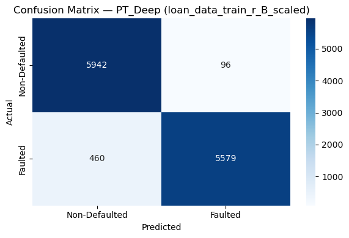

```python
# Confusion matrix visualization
cm = confusion_matrix(y_test, y_pred)
plt.figure(figsize=(6, 4))
sns.heatmap(cm, annot=True, fmt='d', cmap='Blues',
            xticklabels=["Non-Defaulted", "Faulted"],
            yticklabels=["Non-Defaulted", "Faulted"])
plt.title(f"Confusion Matrix — {model_key} ({best_dataset_name})")
plt.xlabel("Predicted")
plt.ylabel("Actual")
plt.tight_layout()
plt.show()
```

**ROC Curve and AUC Score**  
The Receiver Operating Characteristic (ROC) curve is a plot of the true positive rate (recall) against the false positive rate across different classification thresholds. The Area Under the Curve (AUC) quantifies the overall ability of the model to discriminate between the classes. An AUC of 1.0 represents perfect separation, while an AUC of 0.5 suggests the model is no better than random guessing.

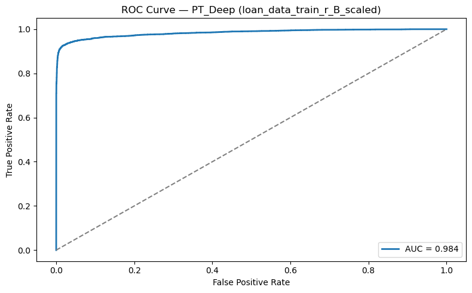

```python
# --- ROC Curve & AUC ---
fpr, tpr, _ = roc_curve(y_test, y_pred_proba)
roc_auc = auc(fpr, tpr)
plt.figure(figsize=(8, 5))
plt.plot(fpr, tpr, label=f"AUC = {roc_auc:.3f}", linewidth=2)
plt.plot([0, 1], [0, 1], linestyle="--", color="gray")
plt.xlabel("False Positive Rate")
plt.ylabel("True Positive Rate")
plt.title(f"ROC Curve — {model_key} ({best_dataset_name})")
plt.legend(loc="lower right")
plt.tight_layout()
plt.show()
```

This ROC curve illustrates the performance of the **Deep PyTorch Neural Network (PT_Deep)** trained on the **`loan_data_train_r_B_scaled`** dataset — the best-performing deep learning configuration in this study.

The ROC curve plots the **True Positive Rate (TPR)** against the **False Positive Rate (FPR)** across all possible classification thresholds. The **blue curve** shows how effectively the neural network distinguishes between *defaulted* and *non-defaulted* loans. The closer the curve hugs the **top-left corner**, the better the model is at maximizing sensitivity while minimizing false positives.

The **gray diagonal line** represents the performance of a random classifier (AUC = 0.5). Any curve above this line indicates skill beyond random guessing.

This performance is consistent with the previously reported **precision**, **recall**, and **F1-score** results, confirming that the deep learning model is not only accurate but also robust and generalizes effectively — making it well-suited for high-stakes, data-driven decision making in credit-risk evaluation.

**Final Conclusion**

This classification report confirms that the **Deep Learning model (PT_Deep)** delivers outstanding performance across both loan classes, achieving **balanced precision and recall** with an overall accuracy of **95%**. The model demonstrates strong generalization, confidently identifying defaulted borrowers while maintaining high reliability in recognizing non-defaulted loans.

Such performance highlights the neural network’s ability to capture complex, nonlinear relationships between borrower attributes, credit history, and loan characteristics—patterns that traditional models may overlook. In a financial context, this level of predictive precision is particularly valuable, as it minimizes both critical types of errors:

- **Approving high-risk borrowers**, which increases default exposure.
- **Rejecting creditworthy clients**, which leads to lost revenue opportunities.

Overall, the Deep Learning model combines **exceptional predictive power** with **robust generalization**, making it a highly effective solution for data-driven credit risk assessment and lending strategy optimization.

**Kaggle Competition Try Out**  
**Loan Approval Prediction: https://www.kaggle.com/competitions/playground-series-s4e10/overview**

```python
loan_data_train_r_B_scaled.head()
```

|  | id | person_age | person_income | person_emp_length | loan_amnt | loan_int_rate | loan_percent_income | cb_person_cred_hist_length | person_home_ownership_OTHER | person_home_ownership_OWN | ... | loan_intent_PERSONAL | loan_intent_VENTURE | loan_grade_B | loan_grade_C | loan_grade_D | loan_grade_E | loan_grade_F | loan_grade_G | cb_person_default_on_file_Y | loan_status |
| --- | --- | --- | --- | --- | --- | --- | --- | --- | --- | --- | --- | --- | --- | --- | --- | --- | --- | --- | --- | --- | --- |
| 0 | 0.193763 | -1.312935 | -1.527564 | 0.333783 | -0.827320 | -1.445808 | 0.714287 | -1.020427 | False | True | ... | False | False | False | False | False | False | False | False | False | 0.0 |
| 1 | 0.020754 | -0.290340 | -1.114813 | -0.638709 | -1.249250 | 1.357805 | -0.849840 | -1.020427 | False | False | ... | False | False | False | False | True | False | False | False | False | 1.0 |
| 2 | 0.526159 | -1.057286 | -0.931369 | -1.287036 | -1.502408 | -0.568465 | -1.371216 | -0.665717 | False | False | ... | False | False | True | False | False | False | False | False | False | 0.0 |
| 3 | -0.722818 | 0.220958 | 0.635754 | -0.314545 | -1.207057 | -0.199398 | -1.371216 | 1.107836 | False | False | ... | False | True | True | False | False | False | False | False | False | 0.0 |
| 4 | 0.882436 | -0.545989 | -0.151728 | -1.287036 | -1.122671 | 0.302403 | -1.162665 | -1.020427 | False | False | ... | False | True | True | False | False | False | False | False | False | 0.0 |

5 rows × 24 columns

```python
# --- Load Kaggle Test Data ---
loan_kaggle_test = pd.read_csv("data/loan_approval_prediction_test.csv")
print("Test shape:", loan_kaggle_test.shape)
```

```
Test shape: (39098, 12)
```

```python
def standardize_dataset_test(df):
    df = df.copy()

    # Identify numeric columns (ignore 'id' if present)
    numeric_cols = df.select_dtypes(include=['int64', 'float64']).columns
    numeric_cols = [col for col in numeric_cols if col != 'id']

    # Apply the same type of scaling as in training
    scaler = StandardScaler()
    df[numeric_cols] = scaler.fit_transform(df[numeric_cols])

    return df
```

```python
# --- Save ID column ---
test_ids = loan_kaggle_test["id"]

# --- Apply same preprocessing as training ---
loan_kaggle_test_scaled = standardize_dataset_test(loan_kaggle_test)
loan_kaggle_test_scaled = pd.get_dummies(loan_kaggle_test_scaled, dummy_na=False)

# --- Align columns with training features ---
training_features = loan_data_train_r_B_scaled.drop(columns=["loan_status"]).columns
loan_kaggle_test_aligned = loan_kaggle_test_scaled.reindex(columns=training_features, fill_value=0)

print("Aligned test shape:", loan_kaggle_test_aligned.shape)
```

```
Aligned test shape: (39098, 23)
```

```python
loan_kaggle_test_aligned
```

|  | id | person_age | person_income | person_emp_length | loan_amnt | loan_int_rate | loan_percent_income | cb_person_cred_hist_length | person_home_ownership_OTHER | person_home_ownership_OWN | ... | loan_intent_MEDICAL | loan_intent_PERSONAL | loan_intent_VENTURE | loan_grade_B | loan_grade_C | loan_grade_D | loan_grade_E | loan_grade_F | loan_grade_G | cb_person_default_on_file_Y |
| --- | --- | --- | --- | --- | --- | --- | --- | --- | --- | --- | --- | --- | --- | --- | --- | --- | --- | --- | --- | --- | --- |
| 0 | 58645 | -0.757007 | 0.130141 | -0.436121 | 2.824250 | 1.688238 | 2.187295 | -0.940719 | False | False | ... | False | False | False | False | False | False | False | True | False | False |
| 1 | 58646 | -0.259715 | 0.841503 | 0.339404 | 0.134238 | 0.668431 | -0.650135 | -0.449573 | False | False | ... | False | True | False | False | True | False | False | False | False | True |
| 2 | 58647 | -0.259715 | -0.897382 | 0.080895 | -0.941767 | 2.161719 | -0.322739 | -0.940719 | False | False | ... | False | False | True | False | False | False | True | False | False | True |
| 3 | 58648 | 0.900631 | -0.370447 | -0.177613 | -0.403765 | -0.583149 | -0.213607 | 0.287147 | False | False | ... | False | False | False | False | False | False | False | False | False | False |
| 4 | 58649 | -0.259715 | 0.999584 | 0.856421 | 1.030908 | 1.873657 | -0.104475 | -0.449573 | False | False | ... | False | False | False | False | False | True | False | False | False | True |
| ... | ... | ... | ... | ... | ... | ... | ... | ... | ... | ... | ... | ... | ... | ... | ... | ... | ... | ... | ... | ... | ... |
| 39093 | 97738 | -0.922770 | -0.865766 | -0.694630 | -1.121101 | -0.096423 | -0.650135 | -0.449573 | False | False | ... | False | False | False | True | False | False | False | False | False | False |
| 39094 | 97739 | -0.922770 | -0.423141 | 0.339404 | -0.403765 | -1.533423 | -0.104475 | -0.695146 | False | False | ... | False | False | False | False | False | False | False | False | False | False |
| 39095 | 97740 | 3.884377 | -0.106980 | -1.211647 | 1.030908 | -1.043386 | 0.986844 | 4.707466 | False | False | ... | False | True | False | False | False | False | False | False | False | False |
| 39096 | 97741 | -0.922770 | -0.739302 | -0.177613 | 0.851574 | 1.641883 | 2.514691 | -0.449573 | False | False | ... | False | True | False | False | False | True | False | False | False | True |
| 39097 | 97742 | 0.569103 | -0.502181 | 0.339404 | 1.828945 | -0.248732 | 3.060350 | 0.778293 | False | False | ... | False | False | False | True | False | False | False | False | False | False |

39098 rows × 23 columns

```python
# --- Force full numeric conversion (and inspect dtypes) ---
for col in loan_kaggle_test_aligned.columns:
    loan_kaggle_test_aligned[col] = pd.to_numeric(loan_kaggle_test_aligned[col], errors='coerce')

# Replace NaNs (if any) with 0
loan_kaggle_test_aligned = loan_kaggle_test_aligned.fillna(0)

# --- Double-check all dtypes ---
print(loan_kaggle_test_aligned.dtypes.value_counts())
print("Any object columns left?:", loan_kaggle_test_aligned.select_dtypes(include=['object']).shape[1])

# --- Finally, convert to tensor ---
X_kaggle = torch.tensor(loan_kaggle_test_aligned.to_numpy(dtype=np.float32))

# --- Switch model to evaluation mode ---
model.eval()
with torch.no_grad():
    y_pred_probs = model(X_kaggle).squeeze()
    y_pred = (y_pred_probs >= 0.5).int().numpy()  # Threshold at 0.5 for binary classification

# --- Build submission file ---
submission = pd.DataFrame({
    "id": test_ids,
    "loan_status": y_pred
})

# --- Save submission to CSV ---
submission.to_csv("kaggle_submission.csv", index=False)
print("Submission file created successfully!")
print(submission.head())
```

```
bool       15
float64     7
int64       1
Name: count, dtype: int64
Any object columns left?: 0
Submission file created successfully!
      id  loan_status
0  58645            0
1  58646            0
2  58647            0
3  58648            0
4  58649            0
```